# Avaliação de técnicas de mineração de dados

Mauricio Gallo - RM: 336168 / Rafael Favretti da Silva RM: 335332

25/01/2020

# Introdução

Durante esse trabalho iremos realizar análises estatísticas sobre diferentes tipos de vinhos.

# Avaliação em função das características físico-químicas

Nossa primeira análise consiste em estimar as características físico-químicas em função da qualidade dos vinhos.

O primeiro passo da nossa análise consiste em importar os dados de uma base em Excel e verificar se todos os dados de características e qualidade estão em um formato númerico, que permita a sua manipulação.

```r
#Importa o dataset
wineData <- read.csv2("D:/BaseWine_Red_e_White.csv", row.names=1)

#Verifica variáveis
str(wineData)
```

```
## 'data.frame':    6497 obs. of  13 variables:
##  $ fixedacidity      : num  6.6 6.7 10.6 5.4 6.7 6.8 6.6 7.2 5.1 6.2 ...
##  $ volatileacidity   : num  0.24 0.34 0.31 0.18 0.3 0.5 0.61 0.66 0.26 0.22 ...
##  $ citricacid        : num  0.35 0.43 0.49 0.24 0.44 0.11 0 0.33 0.33 0.2 ...
##  $ residualsugar     : num  7.7 1.6 2.2 4.8 18.8 ...
##  $ chlorides         : num  0.031 0.041 0.063 0.041 0.057 0.075 0.069 0.068 0.027 0.035 ...
##  $ freesulfurdioxide : num  36 29 18 30 65 16 4 34 46 58 ...
##  $ totalsulfurdioxide: num  135 114 40 113 224 49 8 102 113 184 ...
##  $ density           : num  0.994 0.99 0.998 0.994 1 ...
##  $ pH                : num  3.19 3.23 3.14 3.42 3.11 3.36 3.33 3.27 3.35 3.11 ...
##  $ sulphates         : num  0.37 0.44 0.51 0.4 0.53 0.79 0.37 0.78 0.43 0.53 ...
##  $ alcohol           : num  10.5 12.6 9.8 9.4 9.1 9.5 10.4 12.8 11.4 9 ...
##  $ quality           : int  5 6 6 6 5 5 4 6 7 6 ...
##  $ Vinho             : Factor w/ 2 levels "RED","WHITE": 2 2 1 2 2 1 1 1 2 2 ...
```

E checar as informações de “Summary” dos dados:

```
##   fixedacidity    volatileacidity    citricacid     residualsugar
##  Min.   : 3.800   Min.   :0.0800   Min.   :0.0000   Min.   : 0.60
##  1st Qu.: 6.400   1st Qu.:0.2300   1st Qu.:0.2500   1st Qu.: 1.80
##  Median : 7.000   Median :0.2900   Median :0.3100   Median : 3.00
##  Mean   : 7.215   Mean   :0.3397   Mean   :0.3186   Mean   : 5.44
##  3rd Qu.: 7.700   3rd Qu.:0.4000   3rd Qu.:0.3900   3rd Qu.: 8.10
##  Max.   :15.900   Max.   :1.5800   Max.   :1.6600   Max.   :45.80
##    chlorides       freesulfurdioxide totalsulfurdioxide    density
##  Min.   :0.00900   Min.   :  1.00    Min.   :  6.0      Min.   :0.9871
##  1st Qu.:0.03800   1st Qu.: 17.00    1st Qu.: 77.0      1st Qu.:0.9923
##  Median :0.04700   Median : 29.00    Median :118.0      Median :0.9949
##  Mean   :0.05603   Mean   : 30.53    Mean   :115.7      Mean   :0.9947
##  3rd Qu.:0.06500   3rd Qu.: 41.00    3rd Qu.:156.0      3rd Qu.:0.9970
##  Max.   :0.61100   Max.   :289.00    Max.   :440.0      Max.   :1.0140
##        pH          sulphates         alcohol           quality
##  Min.   :2.720   Min.   :0.2200   Min.   : 0.9567   Min.   :3.000
##  1st Qu.:3.110   1st Qu.:0.4300   1st Qu.: 9.5000   1st Qu.:5.000
##  Median :3.210   Median :0.5100   Median :10.3000   Median :6.000
##  Mean   :3.219   Mean   :0.5313   Mean   :10.4862   Mean   :5.818
##  3rd Qu.:3.320   3rd Qu.:0.6000   3rd Qu.:11.3000   3rd Qu.:6.000
##  Max.   :4.010   Max.   :2.0000   Max.   :14.9000   Max.   :9.000
##    Vinho
##  RED  :1599
##  WHITE:4898
##
##
##
##
```

Vamos analisar os dados das características físico-quimicas através de um boxplot para verificar possíveis outliers nos dados:

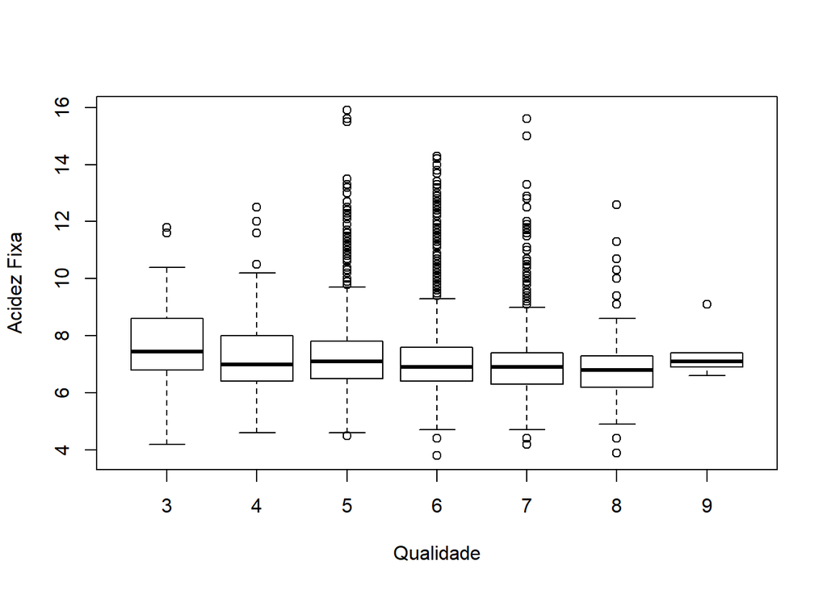

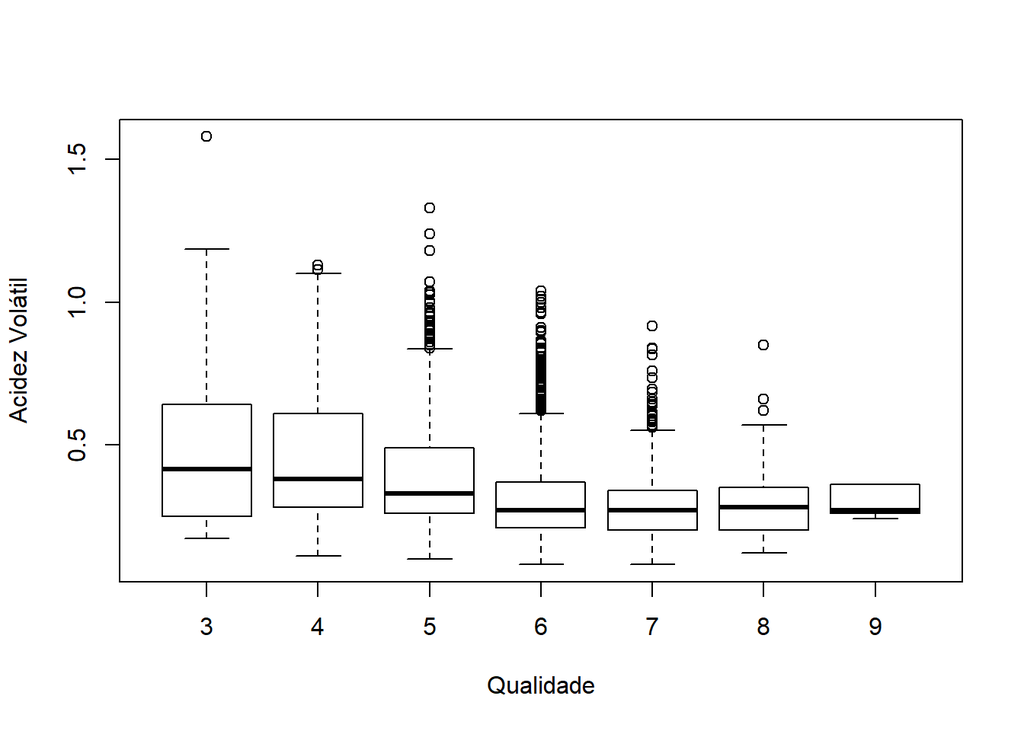

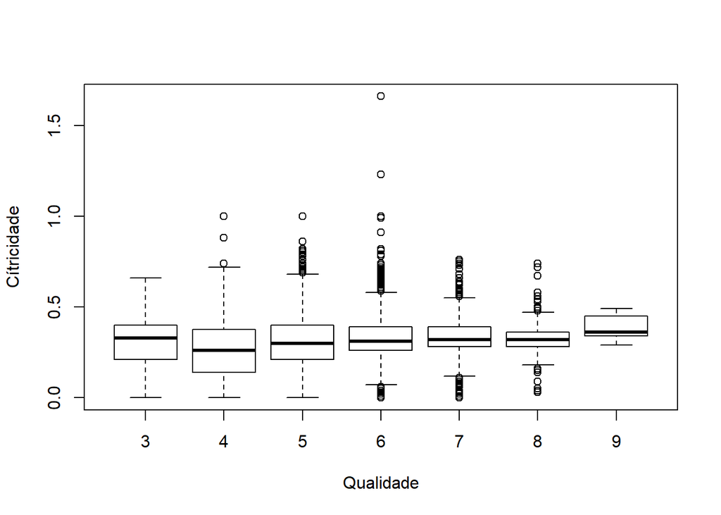

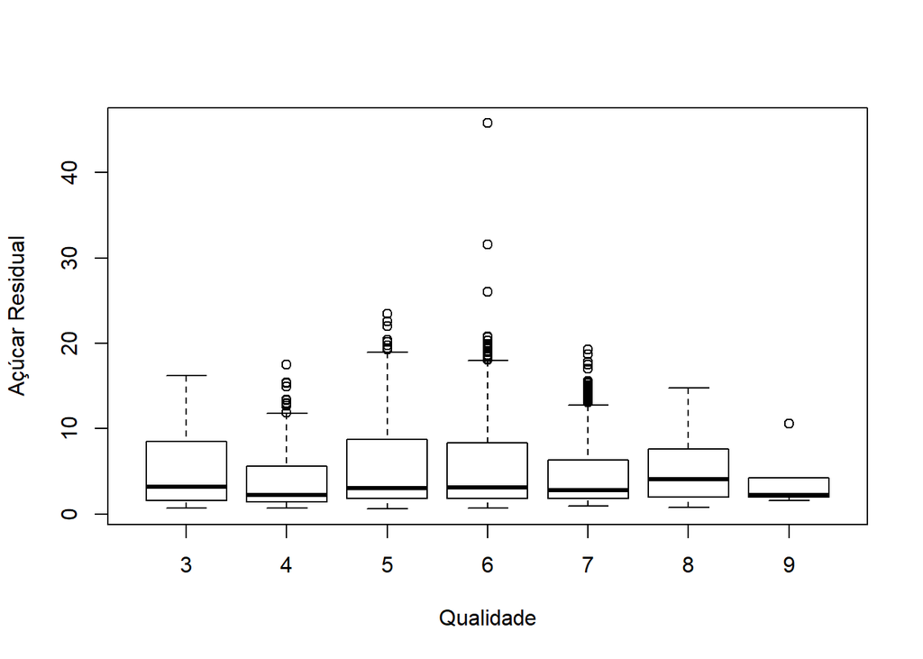

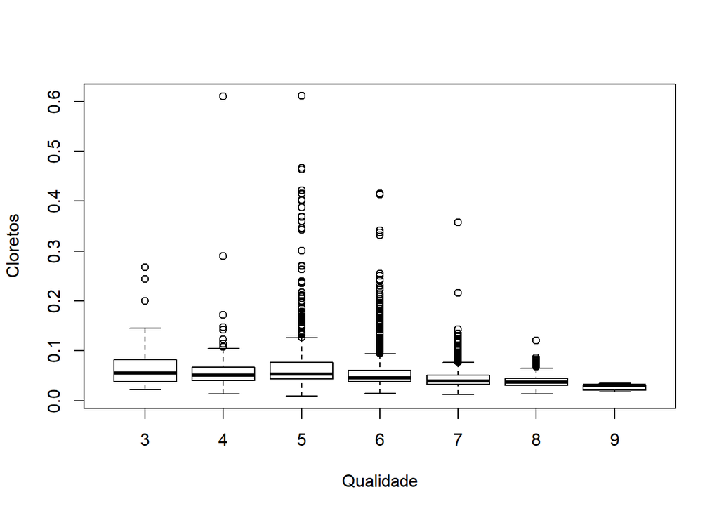

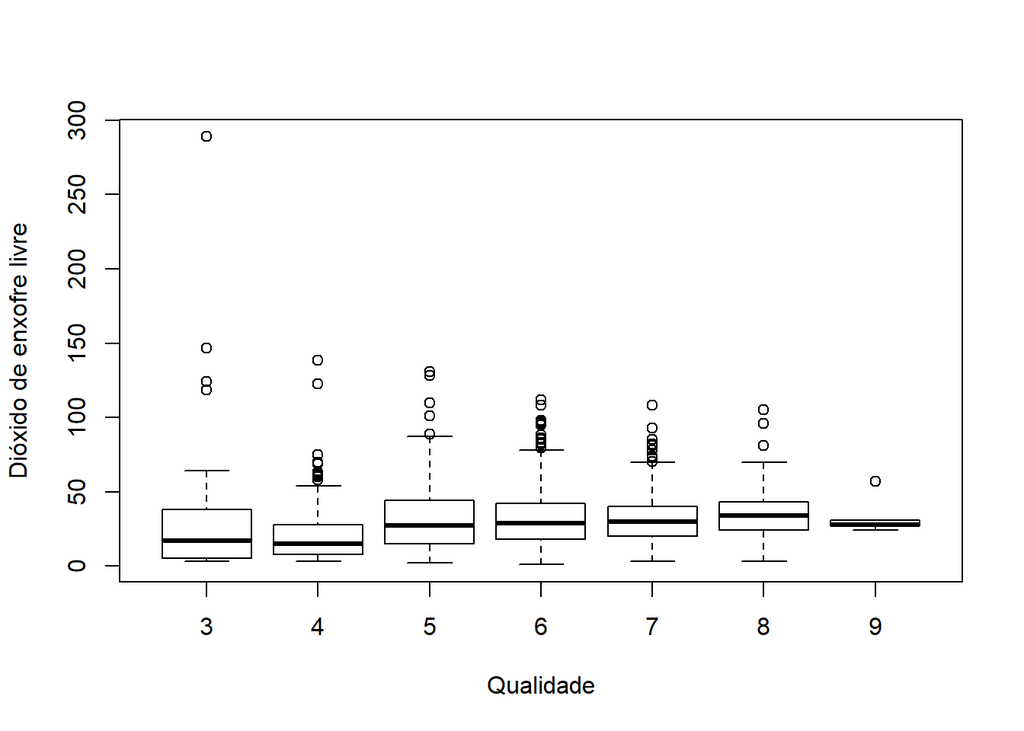

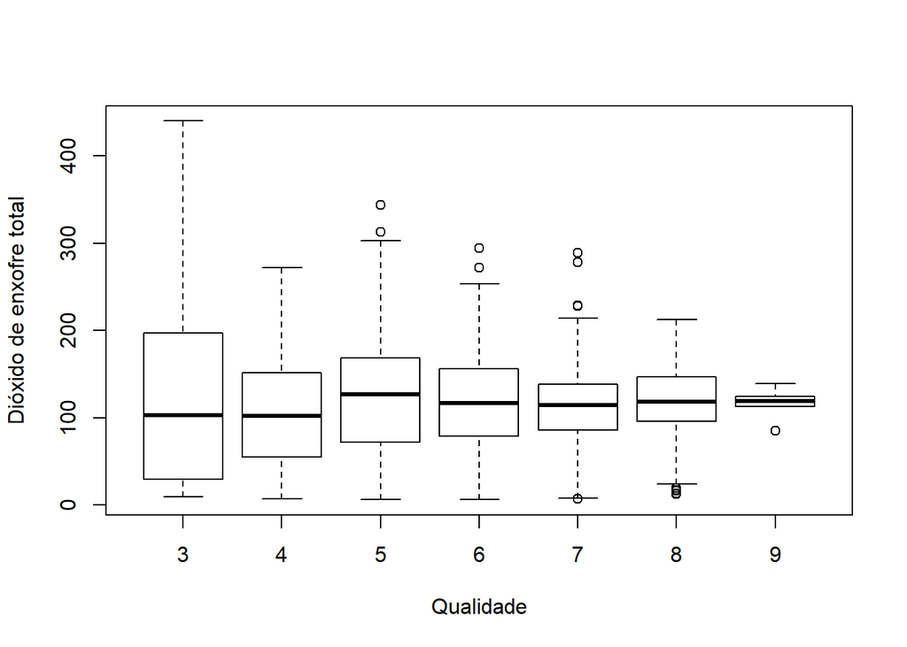

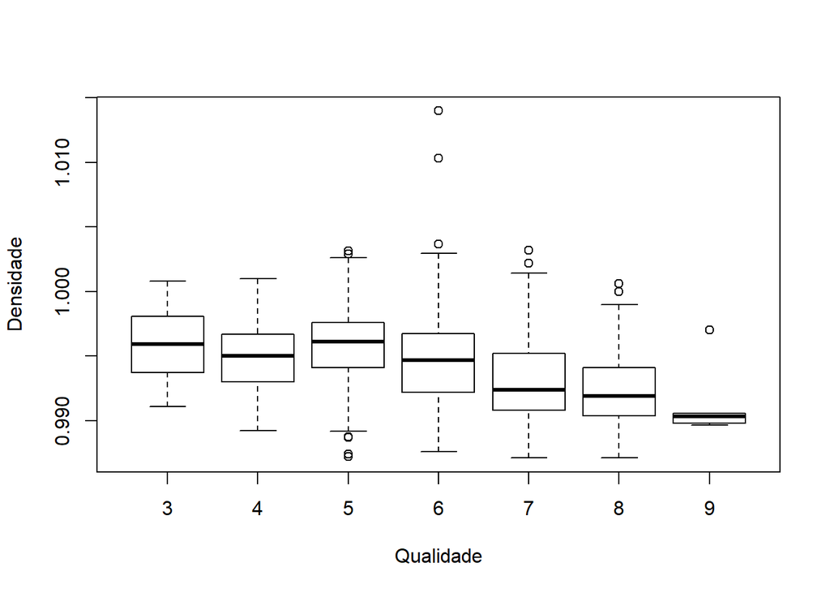

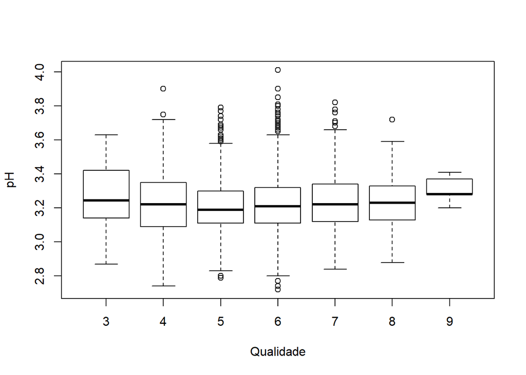

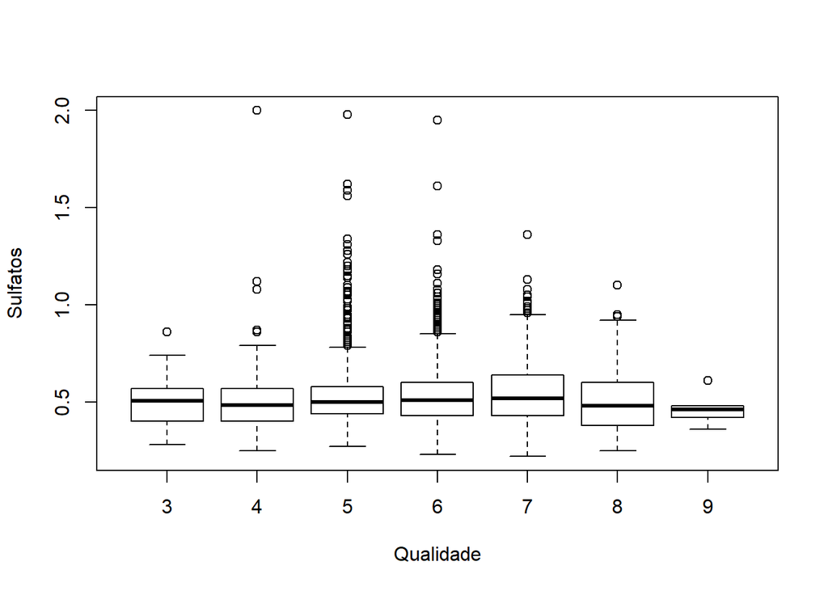

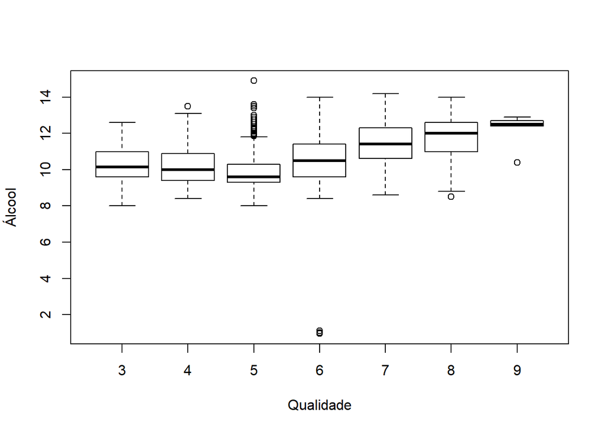

Feito isso, definimos um valor de desvio padrão de 3 para aprofundar a análise e permitir uma definição melhor dos outliers e executamos novamente os boxplot:

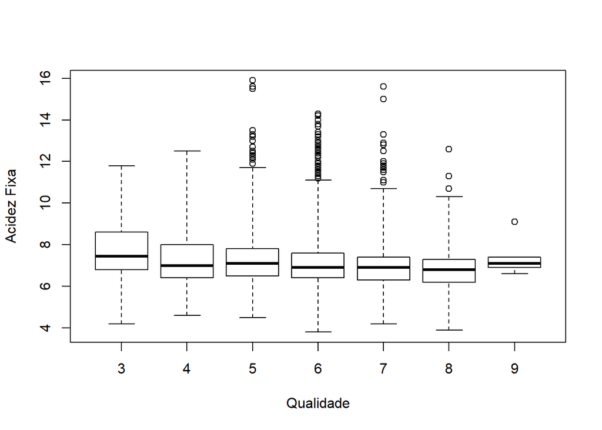

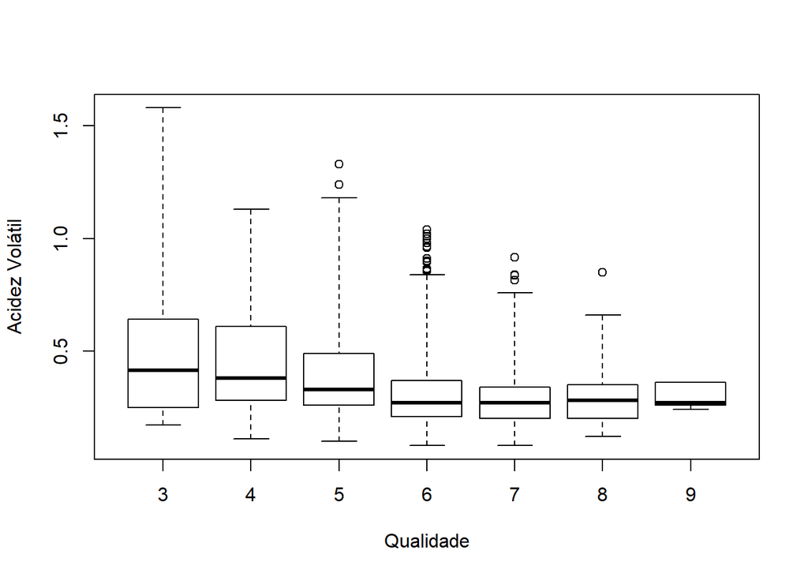

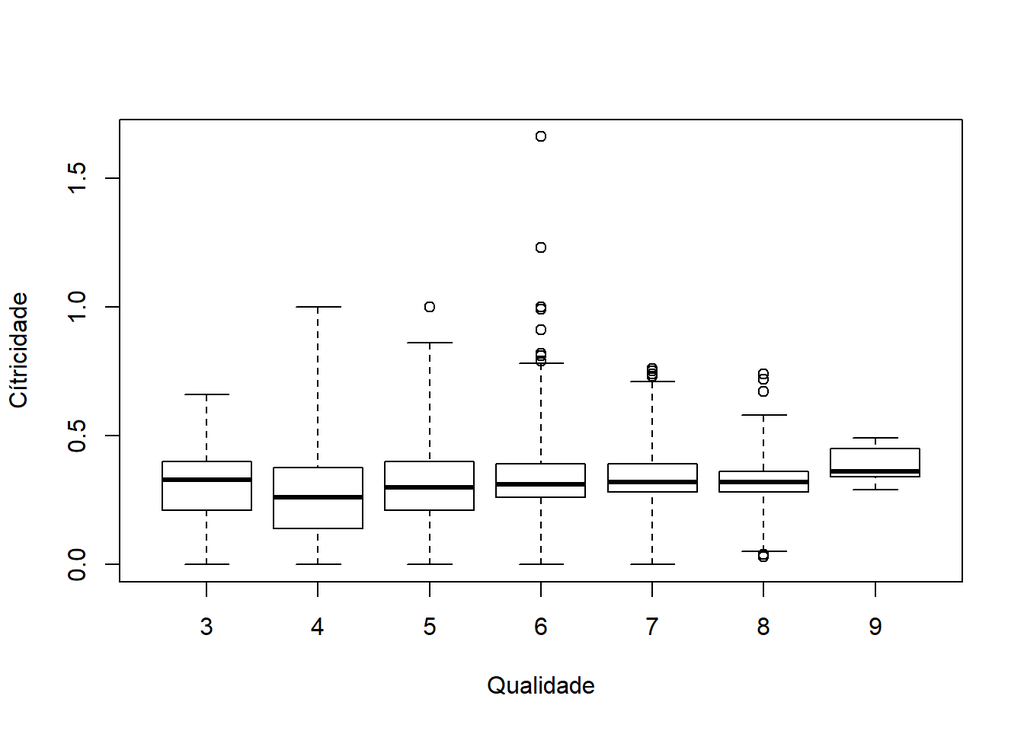

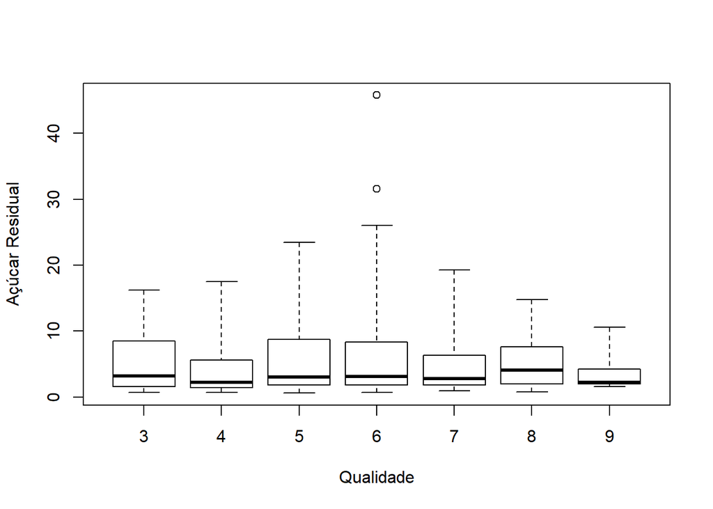

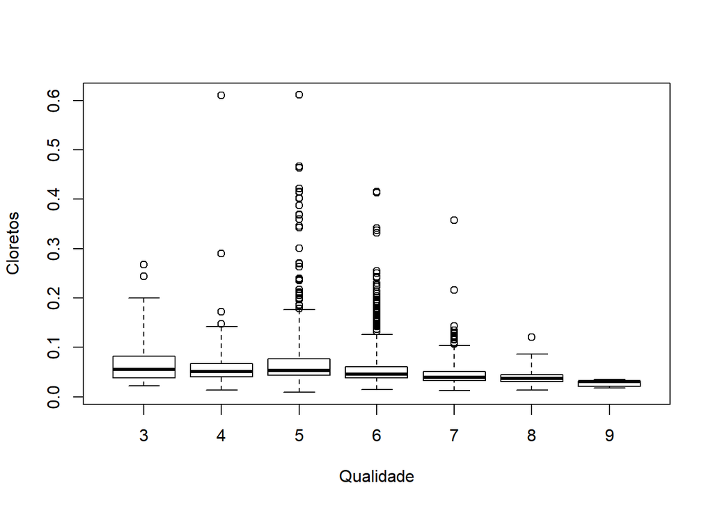

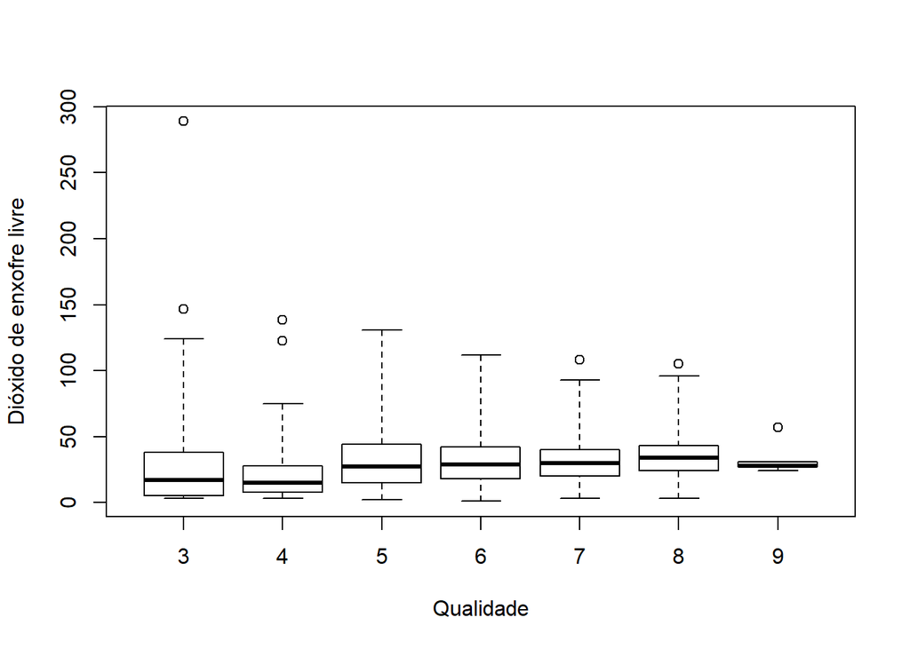

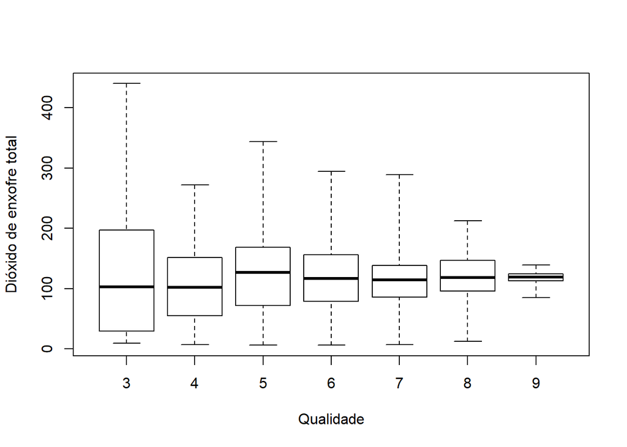

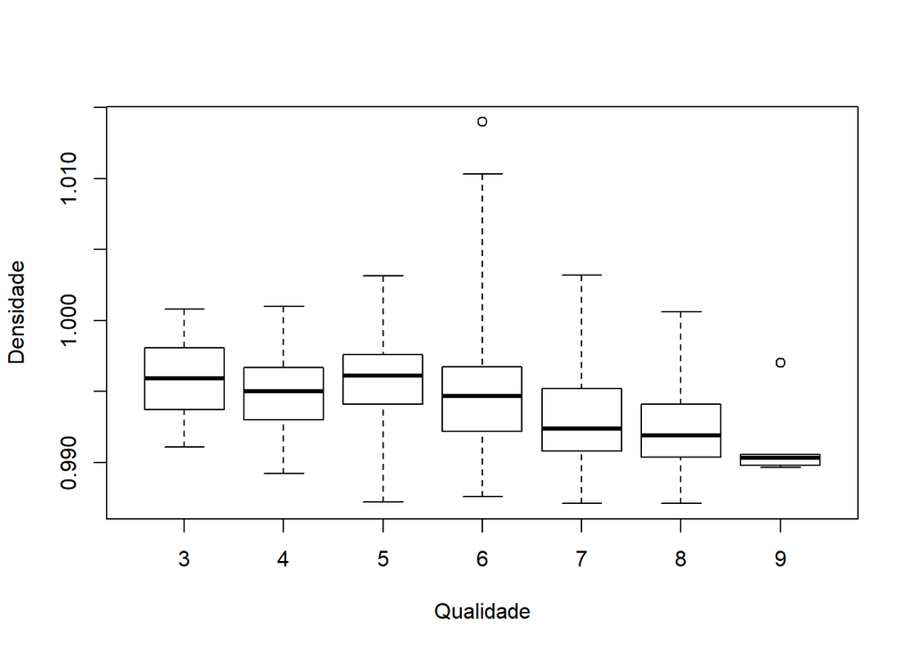

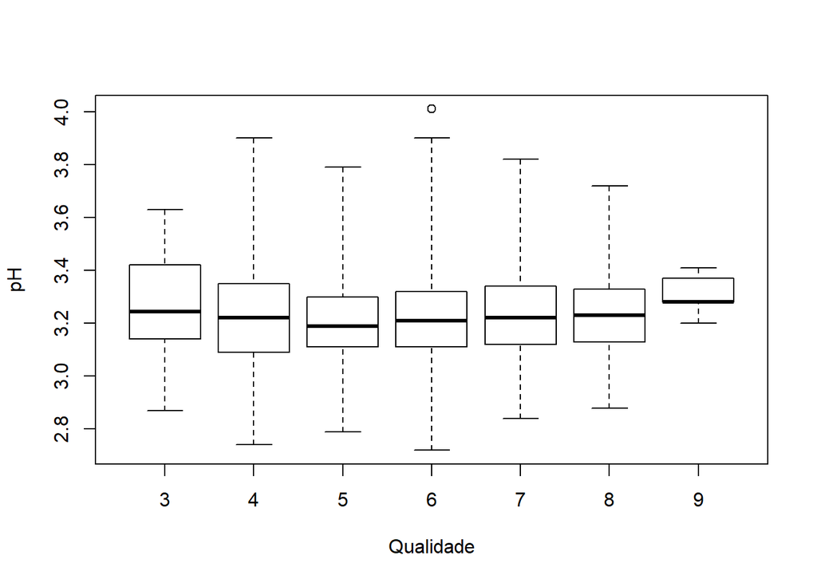

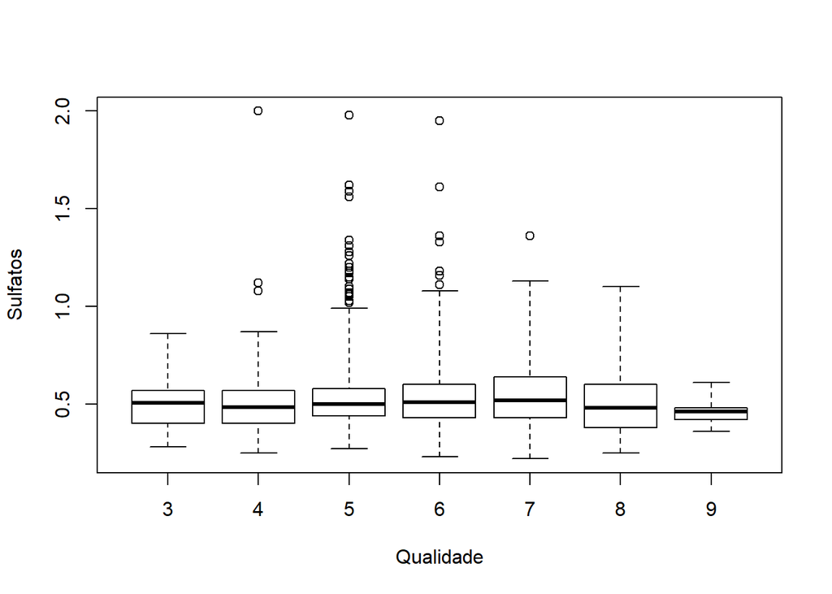

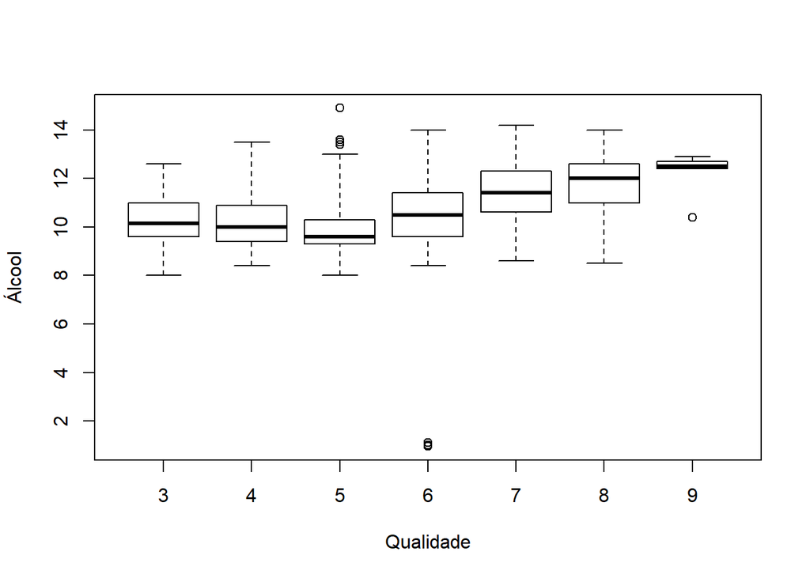

Com os dados apresentados, somos capazes de detectar os níveis dos outliers e filtrar os dados eliminando os que possam impactar na análise dos dados:

```r
#Começamos a remover os outliers da base
wineData %>% filter(fixedacidity <= 13) -> filtered
filtered %>% filter(volatileacidity <= 1.3) -> filtered
filtered %>% filter(citricacid <= 1) -> filtered
filtered %>% filter(residualsugar <= 25) -> filtered
filtered %>% filter(chlorides <= 0.2) -> filtered
filtered %>% filter(freesulfurdioxide <= 140) -> filtered
filtered %>% filter(density <= 1.010) -> filtered
filtered %>% filter(pH <= 3.5) -> filtered
filtered %>% filter(sulphates <= 1.5) -> filtered
filtered %>% filter(alcohol > 8) -> filtered
```

Feito isso, geramos novamente o gráfico de boxplot para análise dos dados:

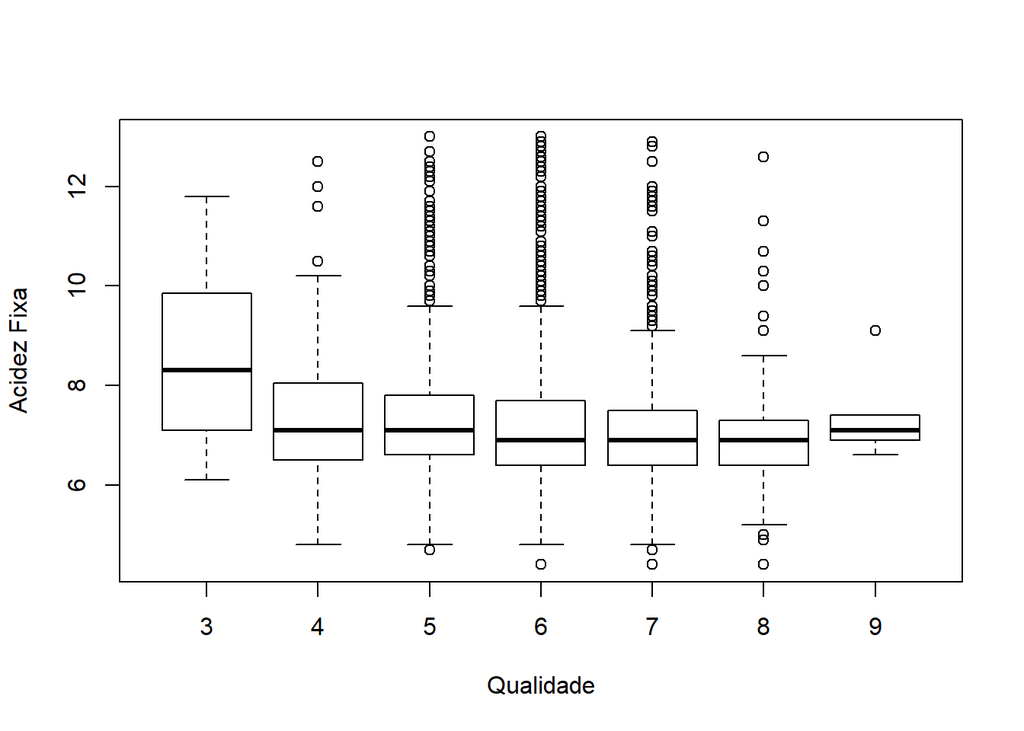

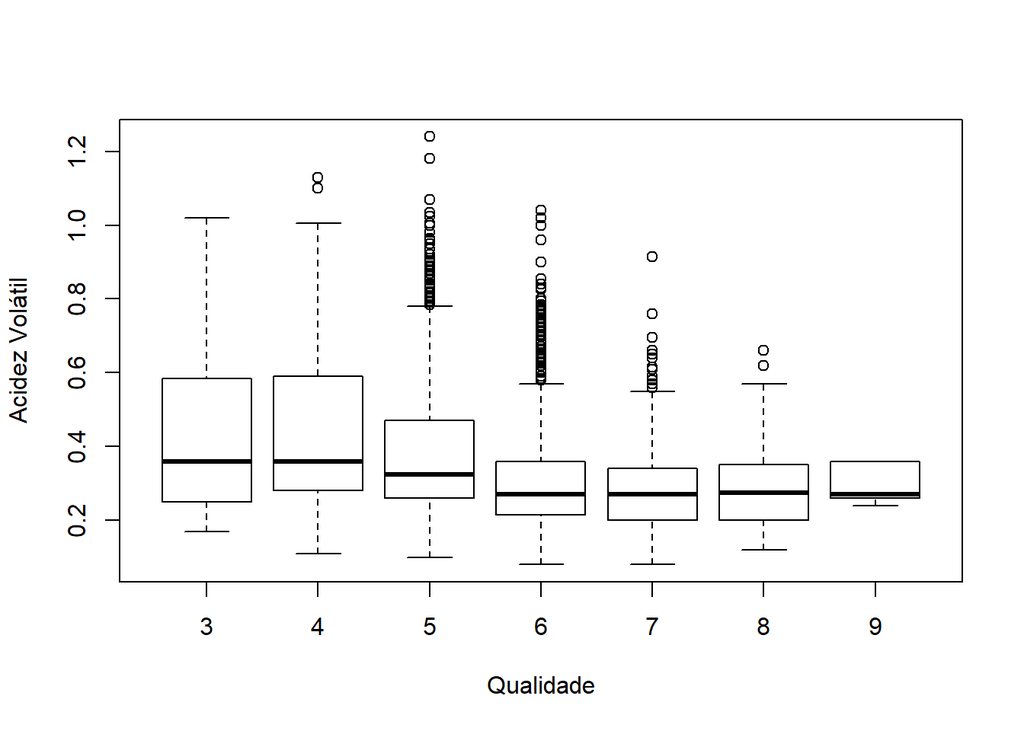

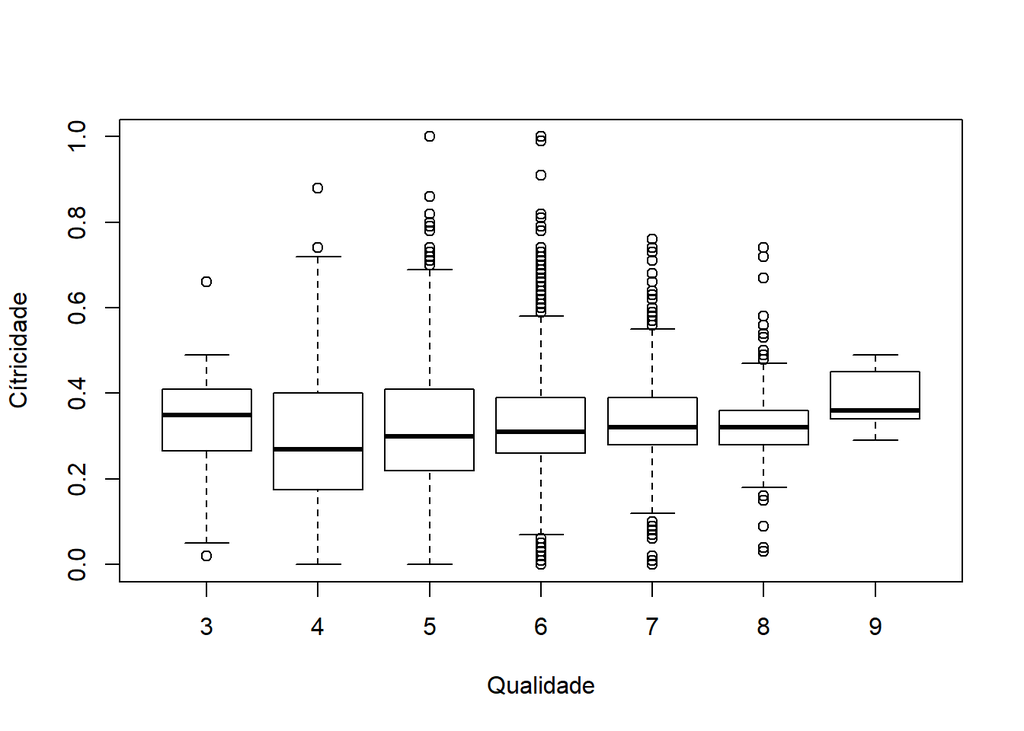

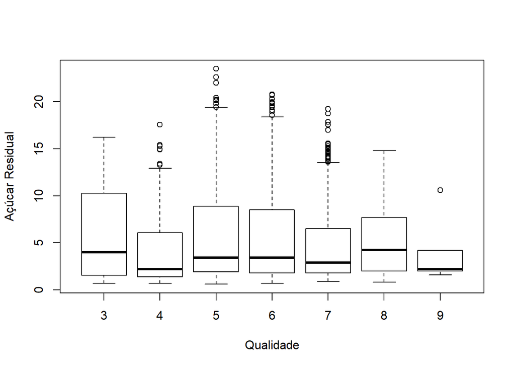

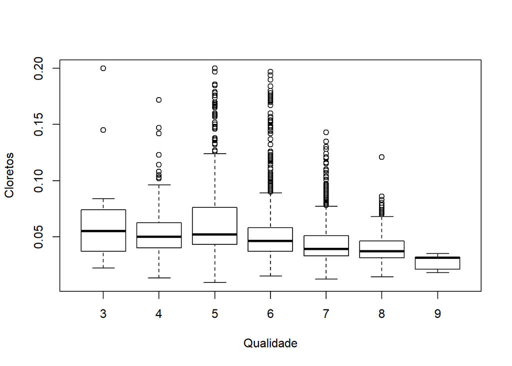

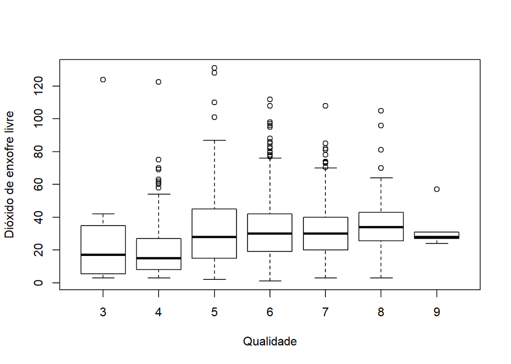

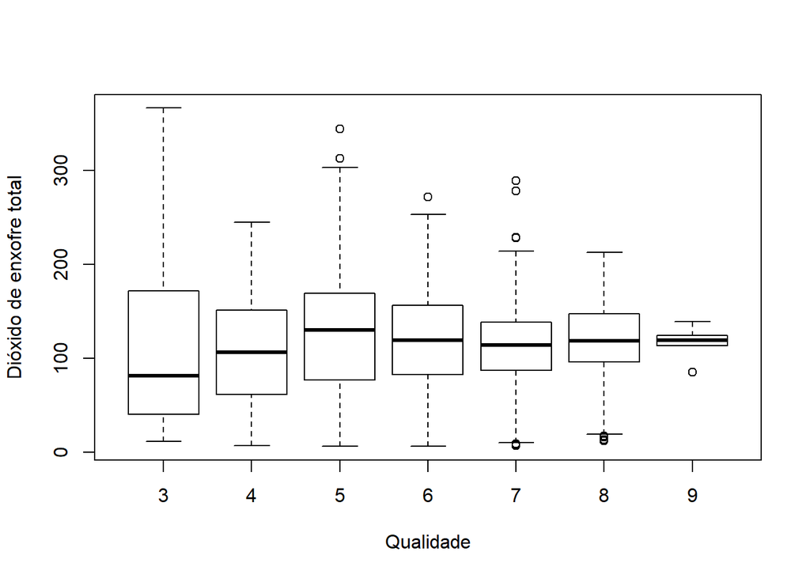

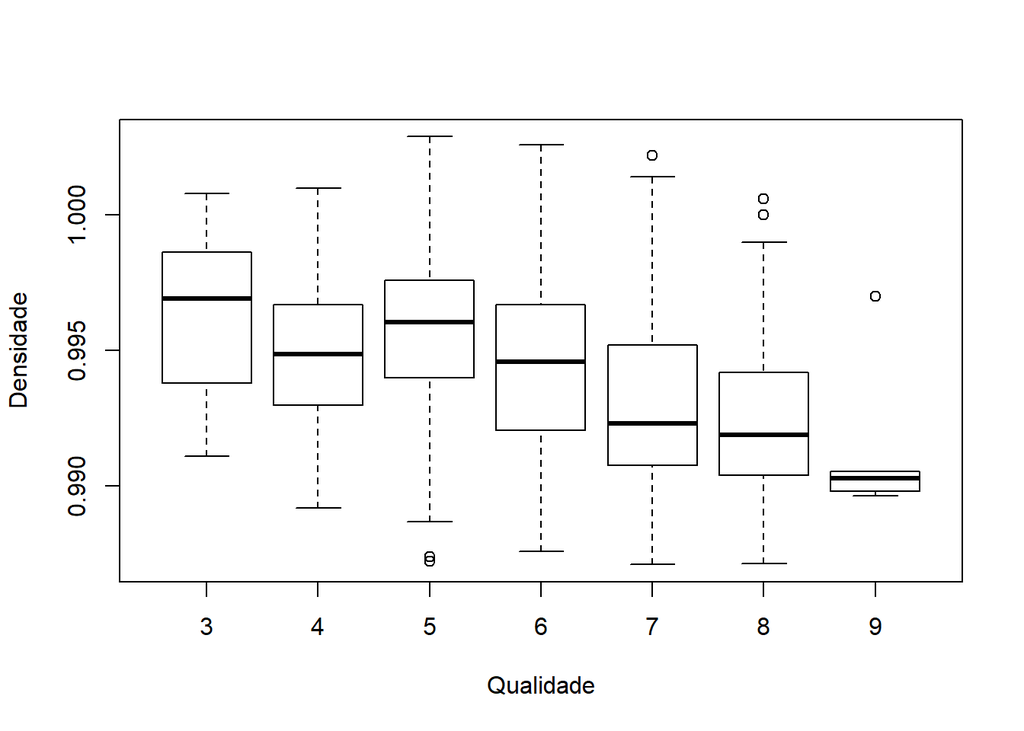

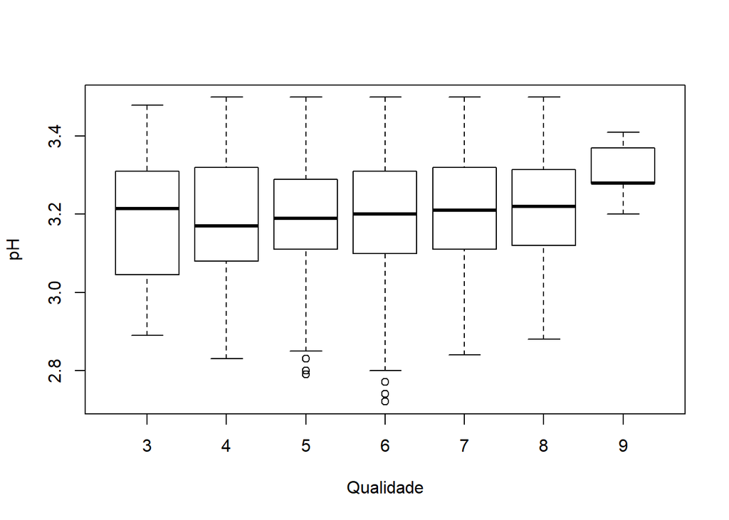

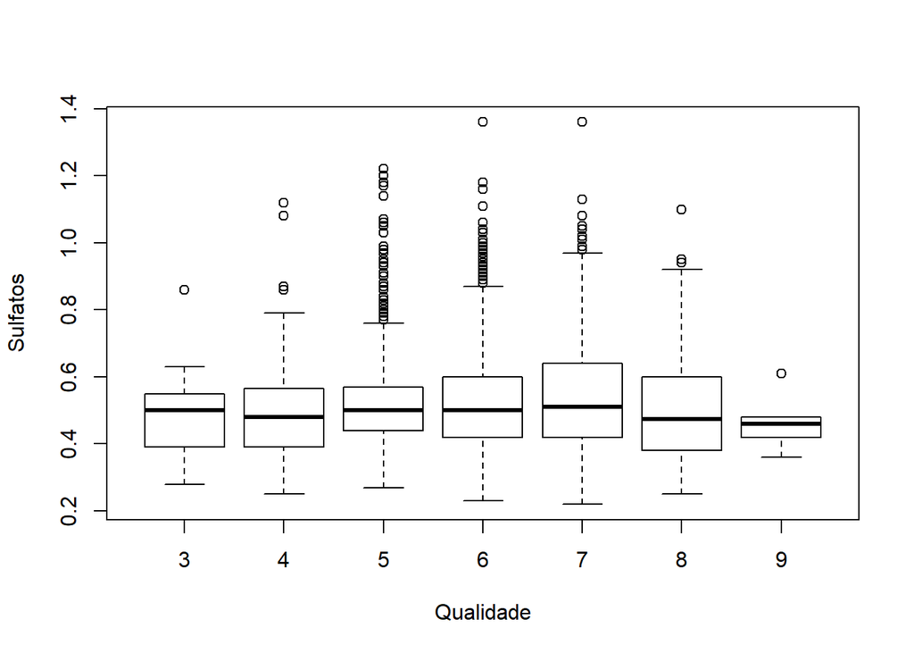

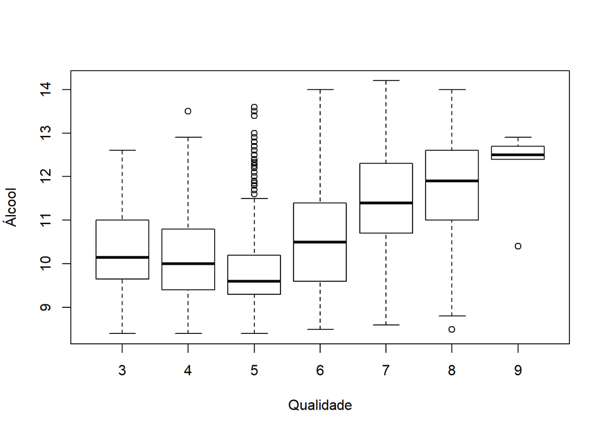

Executamos em seguida uma matriz de correlação nos dados filtrados para ver melhor a correlação dos dados:

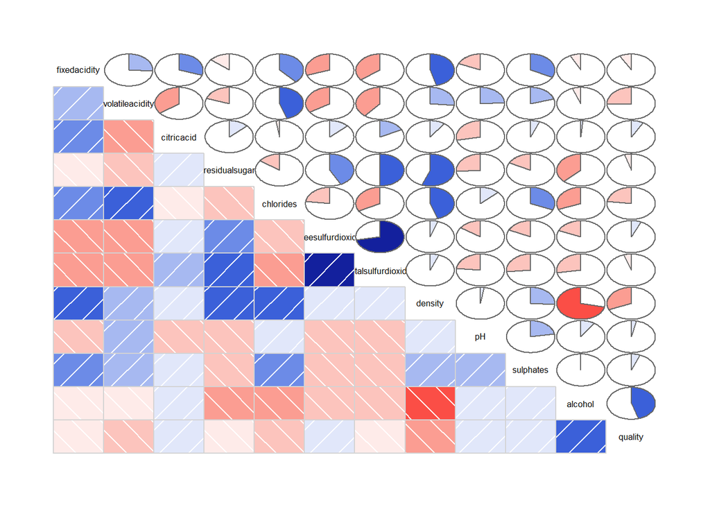

```r
#Rodar matriz de correlação
corMatrix <- cor(filtered %>% select(-Vinho))

#Visualizar a matriz de correlação
corrgram(corMatrix, type = "cor", lower.panel = panel.shade, upper.panel = panel.pie)
```

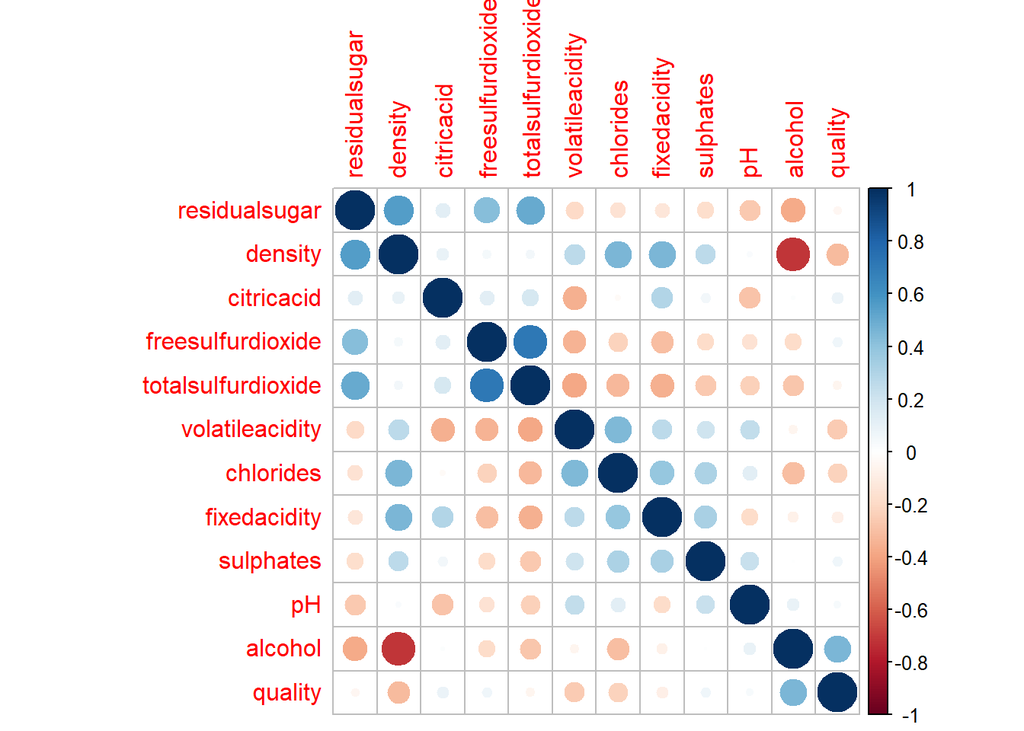

```r
corrplot::corrplot(corMatrix, method="circle", order="hclust")
```

Com os dados em ordem podemos então executar um modelo de regressão linear:

```r
# Modelo de regressão linear
regressionModel <- lm(filtered$quality ~ filtered$fixedacidity + filtered$citricacid + filtered$residualsugar + filtered$chlorides + filtered$freesulfurdioxide + filtered$totalsulfurdioxide + filtered$density + filtered$pH + filtered$sulphates + filtered$alcohol)
summary(regressionModel)
```

```
##
## Call:
## lm(formula = filtered$quality ~ filtered$fixedacidity + filtered$citricacid +
##     filtered$residualsugar + filtered$chlorides + filtered$freesulfurdioxide +
##     filtered$totalsulfurdioxide + filtered$density + filtered$pH +
##     filtered$sulphates + filtered$alcohol)
##
## Residuals:
##     Min      1Q  Median      3Q     Max
## -3.6625 -0.4823 -0.0599  0.4698  2.9842
##
## Coefficients:
##                               Estimate Std. Error t value Pr(>|t|)
## (Intercept)                  1.340e+02  1.353e+01   9.906  < 2e-16 ***
## filtered$fixedacidity        1.122e-01  1.766e-02   6.352 2.27e-10 ***
## filtered$citricacid          3.462e-01  7.874e-02   4.397 1.12e-05 ***
## filtered$residualsugar       7.035e-02  5.630e-03  12.495  < 2e-16 ***
## filtered$chlorides          -1.038e+00  5.416e-01  -1.917   0.0553 .
## filtered$freesulfurdioxide   8.580e-03  8.006e-04  10.717  < 2e-16 ***
## filtered$totalsulfurdioxide -2.531e-03  2.896e-04  -8.742  < 2e-16 ***
## filtered$density            -1.350e+02  1.380e+01  -9.782  < 2e-16 ***
## filtered$pH                  7.719e-01  1.033e-01   7.473 8.97e-14 ***
## filtered$sulphates           1.013e+00  8.492e-02  11.925  < 2e-16 ***
## filtered$alcohol             1.801e-01  1.846e-02   9.756  < 2e-16 ***
## ---
## Signif. codes:  0 '***' 0.001 '**' 0.01 '*' 0.05 '.' 0.1 ' ' 1
##
## Residual standard error: 0.742 on 6077 degrees of freedom
## Multiple R-squared:  0.2691, Adjusted R-squared:  0.2679
## F-statistic: 223.8 on 10 and 6077 DF,  p-value: < 2.2e-16
```

```r
stepwise<-step(regressionModel,direction="both")
```

```
## Start:  AIC=-3622.57
## filtered$quality ~ filtered$fixedacidity + filtered$citricacid +
##     filtered$residualsugar + filtered$chlorides + filtered$freesulfurdioxide +
##     filtered$totalsulfurdioxide + filtered$density + filtered$pH +
##     filtered$sulphates + filtered$alcohol
##
##                               Df Sum of Sq    RSS     AIC
## <none>                                     3345.7 -3622.6
## - filtered$chlorides           1     2.023 3347.7 -3620.9
## - filtered$citricacid          1    10.642 3356.3 -3605.2
## - filtered$fixedacidity        1    22.217 3367.9 -3584.3
## - filtered$pH                  1    30.743 3376.4 -3568.9
## - filtered$totalsulfurdioxide  1    42.073 3387.8 -3548.5
## - filtered$alcohol             1    52.397 3398.1 -3530.0
## - filtered$density             1    52.676 3398.4 -3529.5
## - filtered$freesulfurdioxide   1    63.236 3408.9 -3510.6
## - filtered$sulphates           1    78.290 3424.0 -3483.7
## - filtered$residualsugar       1    85.956 3431.6 -3470.1
```

```r
summary(stepwise)
```

```
##
## Call:
## lm(formula = filtered$quality ~ filtered$fixedacidity + filtered$citricacid +
##     filtered$residualsugar + filtered$chlorides + filtered$freesulfurdioxide +
##     filtered$totalsulfurdioxide + filtered$density + filtered$pH +
##     filtered$sulphates + filtered$alcohol)
##
## Residuals:
##     Min      1Q  Median      3Q     Max
## -3.6625 -0.4823 -0.0599  0.4698  2.9842
##
## Coefficients:
##                               Estimate Std. Error t value Pr(>|t|)
## (Intercept)                  1.340e+02  1.353e+01   9.906  < 2e-16 ***
## filtered$fixedacidity        1.122e-01  1.766e-02   6.352 2.27e-10 ***
## filtered$citricacid          3.462e-01  7.874e-02   4.397 1.12e-05 ***
## filtered$residualsugar       7.035e-02  5.630e-03  12.495  < 2e-16 ***
## filtered$chlorides          -1.038e+00  5.416e-01  -1.917   0.0553 .
## filtered$freesulfurdioxide   8.580e-03  8.006e-04  10.717  < 2e-16 ***
## filtered$totalsulfurdioxide -2.531e-03  2.896e-04  -8.742  < 2e-16 ***
## filtered$density            -1.350e+02  1.380e+01  -9.782  < 2e-16 ***
## filtered$pH                  7.719e-01  1.033e-01   7.473 8.97e-14 ***
## filtered$sulphates           1.013e+00  8.492e-02  11.925  < 2e-16 ***
## filtered$alcohol             1.801e-01  1.846e-02   9.756  < 2e-16 ***
## ---
## Signif. codes:  0 '***' 0.001 '**' 0.01 '*' 0.05 '.' 0.1 ' ' 1
##
## Residual standard error: 0.742 on 6077 degrees of freedom
## Multiple R-squared:  0.2691, Adjusted R-squared:  0.2679
## F-statistic: 223.8 on 10 and 6077 DF,  p-value: < 2.2e-16
```

Além disso rodamos um modelo de árvore de regressão:

```r
regressionTree <- rpart(quality ~ filtered$fixedacidity + filtered$citricacid + filtered$residualsugar + filtered$chlorides + filtered$freesulfurdioxide + filtered$totalsulfurdioxide + filtered$density + filtered$pH + filtered$sulphates + filtered$alcohol,
             data=filtered, cp=0.005)

printcp(regressionTree) # display the results
```

```
##
## Regression tree:
## rpart(formula = quality ~ filtered$fixedacidity + filtered$citricacid +
##     filtered$residualsugar + filtered$chlorides + filtered$freesulfurdioxide +
##     filtered$totalsulfurdioxide + filtered$density + filtered$pH +
##     filtered$sulphates + filtered$alcohol, data = filtered, cp = 0.005)
##
## Variables actually used in tree construction:
## [1] filtered$alcohol           filtered$citricacid
## [3] filtered$fixedacidity      filtered$freesulfurdioxide
## [5] filtered$pH                filtered$residualsugar
## [7] filtered$sulphates
##
## Root node error: 4577.6/6088 = 0.75191
##
## n= 6088
##
##           CP nsplit rel error  xerror     xstd
## 1  0.1717457      0   1.00000 1.00048 0.018904
## 2  0.0285713      1   0.82825 0.82902 0.017650
## 3  0.0146203      2   0.79968 0.80288 0.017093
## 4  0.0087181      3   0.78506 0.78854 0.016802
## 5  0.0085404      4   0.77634 0.77725 0.016514
## 6  0.0084200      5   0.76780 0.77532 0.016431
## 7  0.0083323      6   0.75938 0.77477 0.016303
## 8  0.0079106      7   0.75105 0.77008 0.016180
## 9  0.0073106      8   0.74314 0.76512 0.016082
## 10 0.0059681      9   0.73583 0.75382 0.015785
## 11 0.0053856     10   0.72986 0.75145 0.015744
## 12 0.0052947     11   0.72448 0.74662 0.015661
## 13 0.0051236     12   0.71918 0.74516 0.015603
## 14 0.0050000     13   0.71406 0.74406 0.015565
```

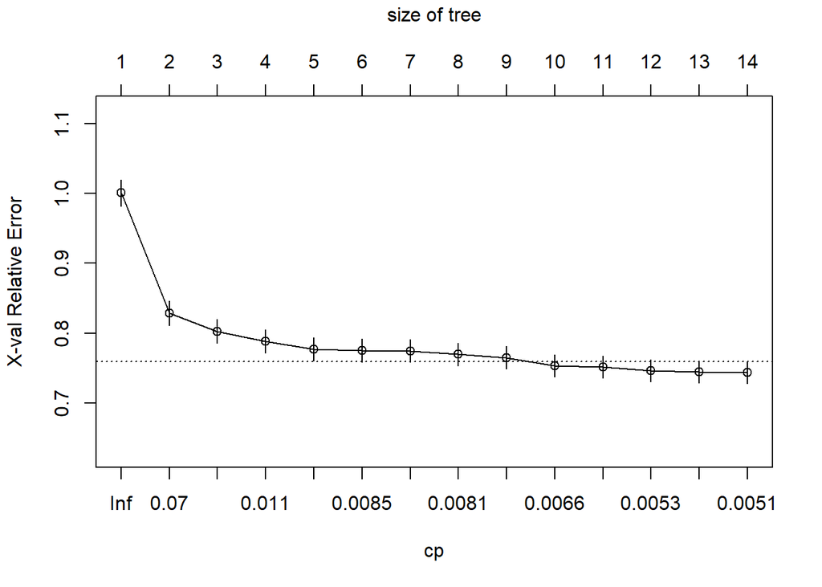

```r
plotcp(regressionTree) # visualize cross-validation results
```

```r
summary(regressionTree) # detailed summary of splits
```

```
## Call:
## rpart(formula = quality ~ filtered$fixedacidity + filtered$citricacid +
##     filtered$residualsugar + filtered$chlorides + filtered$freesulfurdioxide +
##     filtered$totalsulfurdioxide + filtered$density + filtered$pH +
##     filtered$sulphates + filtered$alcohol, data = filtered, cp = 0.005)
##   n= 6088
##
##             CP nsplit rel error    xerror       xstd
## 1  0.171745702      0 1.0000000 1.0004764 0.01890392
## 2  0.028571252      1 0.8282543 0.8290191 0.01765044
## 3  0.014620311      2 0.7996830 0.8028827 0.01709330
## 4  0.008718066      3 0.7850627 0.7885434 0.01680197
## 5  0.008540370      4 0.7763447 0.7772468 0.01651429
## 6  0.008420016      5 0.7678043 0.7753212 0.01643118
## 7  0.008332289      6 0.7593843 0.7747707 0.01630252
## 8  0.007910610      7 0.7510520 0.7700755 0.01617953
## 9  0.007310605      8 0.7431414 0.7651250 0.01608208
## 10 0.005968079      9 0.7358308 0.7538166 0.01578510
## 11 0.005385568     10 0.7298627 0.7514497 0.01574394
## 12 0.005294706     11 0.7244771 0.7466247 0.01566138
## 13 0.005123571     12 0.7191824 0.7451646 0.01560277
## 14 0.005000000     13 0.7140589 0.7440568 0.01556507
##
## Variable importance
##            filtered$alcohol            filtered$density
##                          42                          22
##          filtered$chlorides         filtered$citricacid
##                          13                           7
##      filtered$residualsugar filtered$totalsulfurdioxide
##                           4                           4
##          filtered$sulphates  filtered$freesulfurdioxide
##                           3                           3
##                 filtered$pH       filtered$fixedacidity
##                           2                           2
##
## Node number 1: 6088 observations,    complexity param=0.1717457
##   mean=5.828351, MSE=0.7519098
##   left son=2 (3625 obs) right son=3 (2463 obs)
##   Primary splits:
##       filtered$alcohol            < 10.625    to the left,  improve=0.17174570, (0 missing)
```

[output cut: 216 more lines]

```
##
## Node number 31: 557 observations
##   mean=6.746858, MSE=0.5481275
##
## Node number 40: 276 observations
##   mean=5.224638, MSE=0.5727263
##
## Node number 41: 1004 observations
##   mean=5.553785, MSE=0.5020873
##
## Node number 46: 150 observations
##   mean=5.986667, MSE=0.6264889
##
## Node number 47: 36 observations
##   mean=7.138889, MSE=0.2862654
```

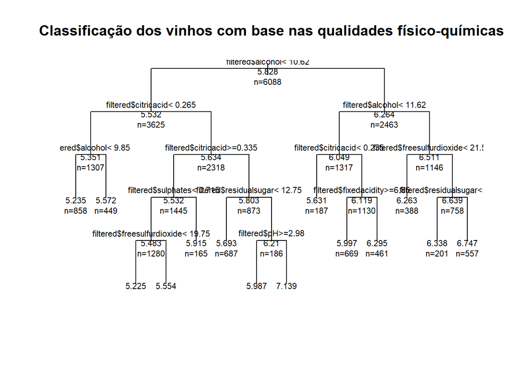

```r
plot(regressionTree, uniform=TRUE,
     main="Classificação dos vinhos com base nas qualidades físico-químicas")
text(regressionTree, use.n=TRUE, all=TRUE, cex=.7)
```

E executamos a validações nos dois modelos para checar qual o mais acertivo:

```r
#Verifica a acertividade do modelo de regressão linear
sqrt(mean((filtered$quality - predict(regressionModel))^2))
```

```
## [1] 0.7413194
```

```r
#Verifica a acertividade do modelo da árvore de regressão
sqrt(mean((filtered$quality - predict(regressionTree))^2))
```

```
## [1] 0.7327399
```

# Avaliação de acordo com classificação bom/ruim

Realizada a análise com base nos fatores físico-químicos, iremos separar os vinhos em 2 classificações: “Bom” ou “Ruim”, sendo que os vinhos considerados ruins serão aqueles com notas abaixo de 6.

Criamos uma nova coluna em nosso dataset, adicionando a classificação de acordo com as notas, e rodamos uma nova verificação dos dados:

```r
#Adiciona uma nova coluna ao dataset
filtered$classificacao <- ifelse(filtered$quality >= 6, "BOM", "RUIM")

#Verifica os dados
str(filtered)
```

```
## 'data.frame':    6088 obs. of  14 variables:
##  $ fixedacidity      : num  6.6 6.7 10.6 5.4 6.7 6.8 6.6 7.2 5.1 6.2 ...
##  $ volatileacidity   : num  0.24 0.34 0.31 0.18 0.3 0.5 0.61 0.66 0.26 0.22 ...
##  $ citricacid        : num  0.35 0.43 0.49 0.24 0.44 0.11 0 0.33 0.33 0.2 ...
##  $ residualsugar     : num  7.7 1.6 2.2 4.8 18.8 ...
##  $ chlorides         : num  0.031 0.041 0.063 0.041 0.057 0.075 0.069 0.068 0.027 0.035 ...
##  $ freesulfurdioxide : num  36 29 18 30 65 16 4 34 46 58 ...
##  $ totalsulfurdioxide: num  135 114 40 113 224 49 8 102 113 184 ...
##  $ density           : num  0.994 0.99 0.998 0.994 1 ...
##  $ pH                : num  3.19 3.23 3.14 3.42 3.11 3.36 3.33 3.27 3.35 3.11 ...
##  $ sulphates         : num  0.37 0.44 0.51 0.4 0.53 0.79 0.37 0.78 0.43 0.53 ...
##  $ alcohol           : num  10.5 12.6 9.8 9.4 9.1 9.5 10.4 12.8 11.4 9 ...
##  $ quality           : int  5 6 6 6 5 5 4 6 7 6 ...
##  $ Vinho             : Factor w/ 2 levels "RED","WHITE": 2 2 1 2 2 1 1 1 2 2 ...
##  $ classificacao     : chr  "RUIM" "BOM" "BOM" "BOM" ...
```

```r
#Transformamos a nova coluna em tipo "Fator"
filtered$classificacao <- factor(filtered$classificacao)

#Checamos novamente o "Summary" do dataset
summary(wineData)
```

```
##   fixedacidity    volatileacidity    citricacid     residualsugar
##  Min.   : 3.800   Min.   :0.0800   Min.   :0.0000   Min.   : 0.60
##  1st Qu.: 6.400   1st Qu.:0.2300   1st Qu.:0.2500   1st Qu.: 1.80
##  Median : 7.000   Median :0.2900   Median :0.3100   Median : 3.00
##  Mean   : 7.215   Mean   :0.3397   Mean   :0.3186   Mean   : 5.44
##  3rd Qu.: 7.700   3rd Qu.:0.4000   3rd Qu.:0.3900   3rd Qu.: 8.10
##  Max.   :15.900   Max.   :1.5800   Max.   :1.6600   Max.   :45.80
##    chlorides       freesulfurdioxide totalsulfurdioxide    density
##  Min.   :0.00900   Min.   :  1.00    Min.   :  6.0      Min.   :0.9871
##  1st Qu.:0.03800   1st Qu.: 17.00    1st Qu.: 77.0      1st Qu.:0.9923
##  Median :0.04700   Median : 29.00    Median :118.0      Median :0.9949
##  Mean   :0.05603   Mean   : 30.53    Mean   :115.7      Mean   :0.9947
##  3rd Qu.:0.06500   3rd Qu.: 41.00    3rd Qu.:156.0      3rd Qu.:0.9970
##  Max.   :0.61100   Max.   :289.00    Max.   :440.0      Max.   :1.0140
##        pH          sulphates         alcohol           quality
##  Min.   :2.720   Min.   :0.2200   Min.   : 0.9567   Min.   :3.000
##  1st Qu.:3.110   1st Qu.:0.4300   1st Qu.: 9.5000   1st Qu.:5.000
##  Median :3.210   Median :0.5100   Median :10.3000   Median :6.000
##  Mean   :3.219   Mean   :0.5313   Mean   :10.4862   Mean   :5.818
##  3rd Qu.:3.320   3rd Qu.:0.6000   3rd Qu.:11.3000   3rd Qu.:6.000
##  Max.   :4.010   Max.   :2.0000   Max.   :14.9000   Max.   :9.000
##    Vinho
##  RED  :1599
##  WHITE:4898
##
##
##
##
```

Feito isso Verificamos os dados através de um boxplot com relação a sua qualidade:

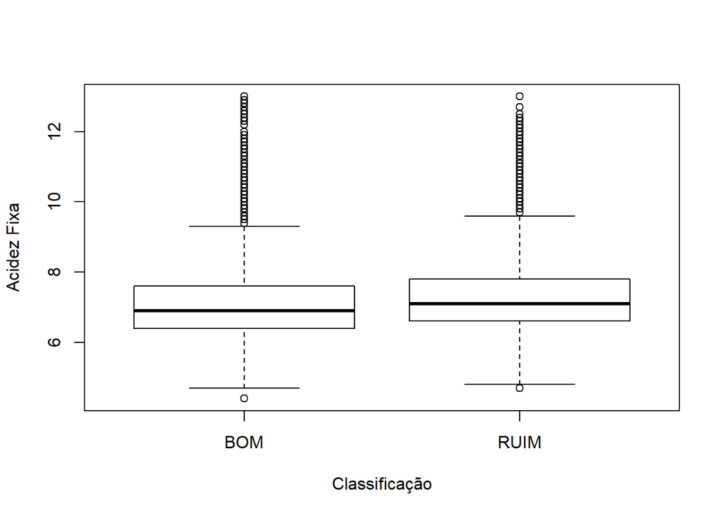

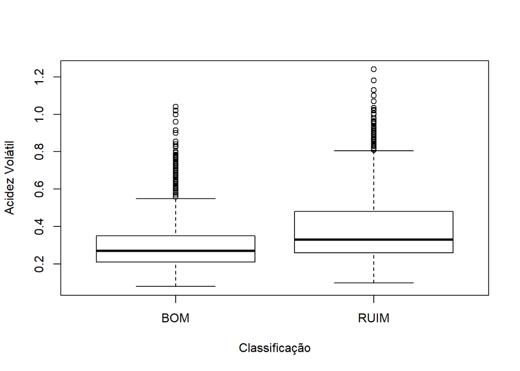

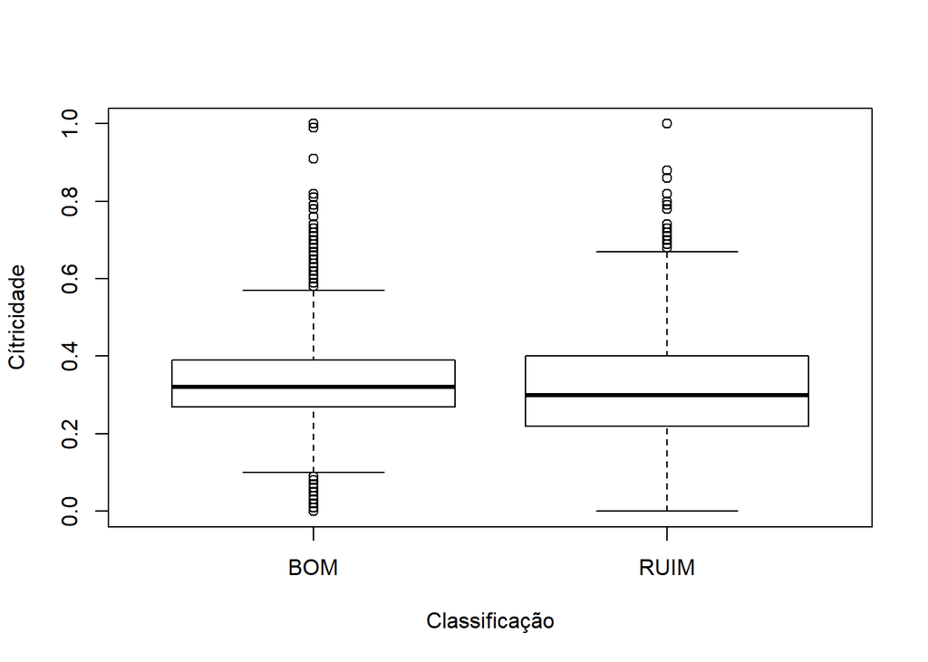

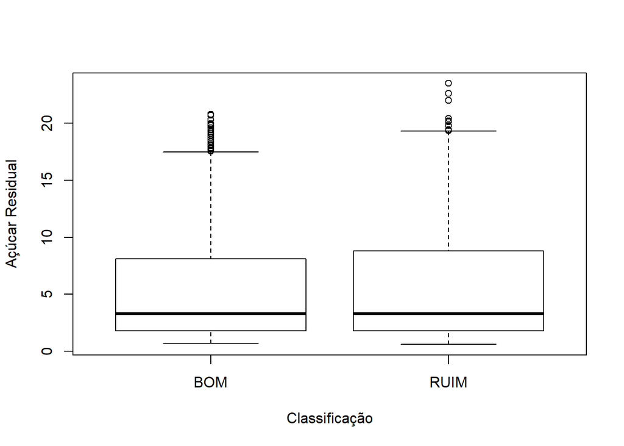

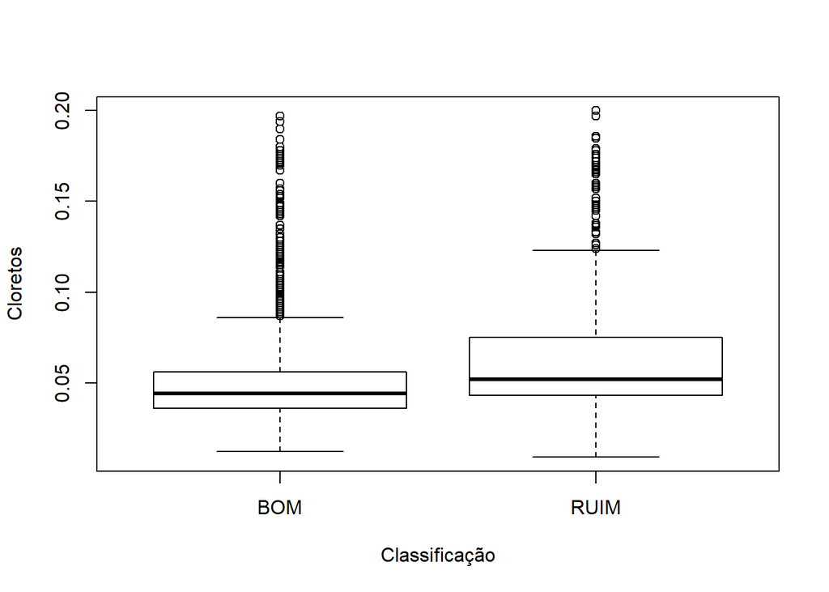

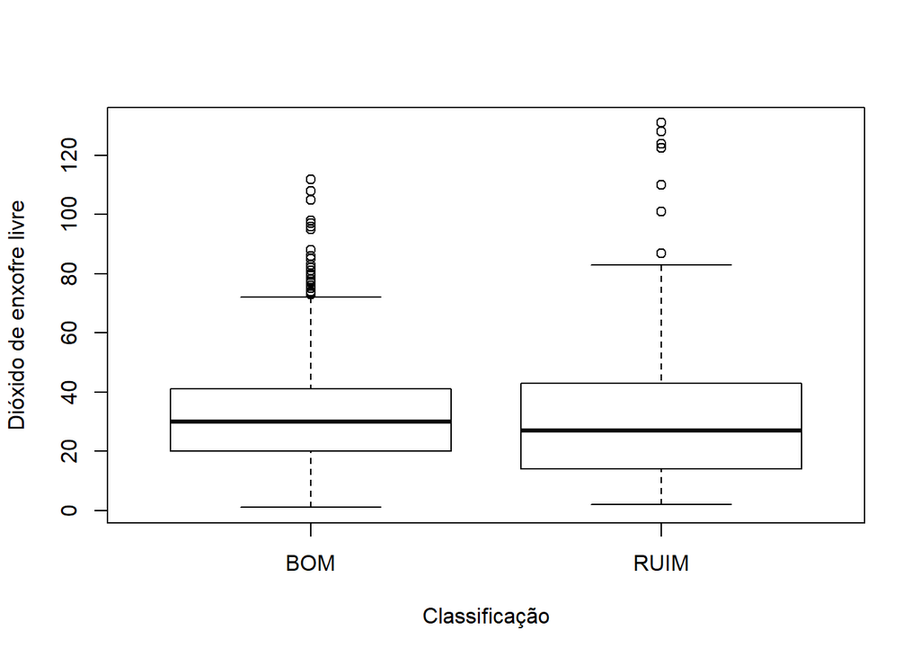

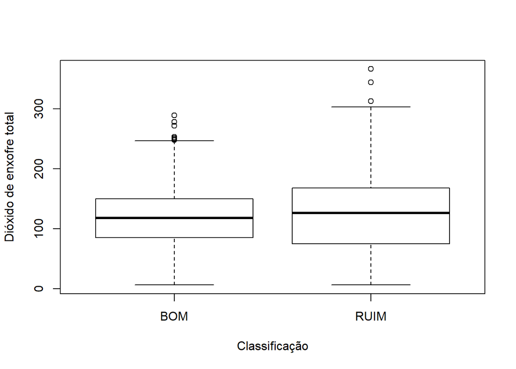

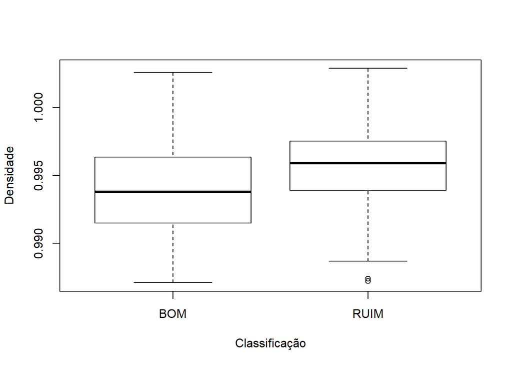

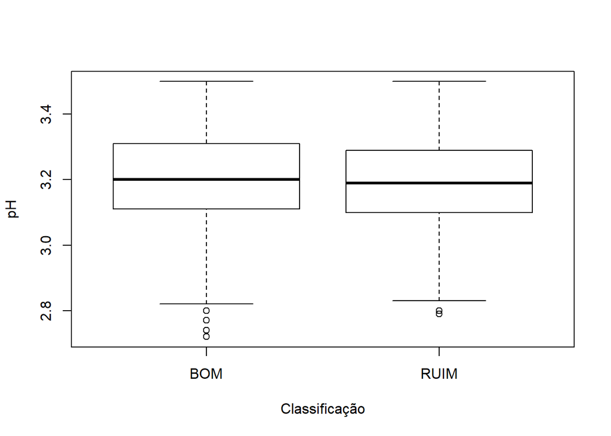

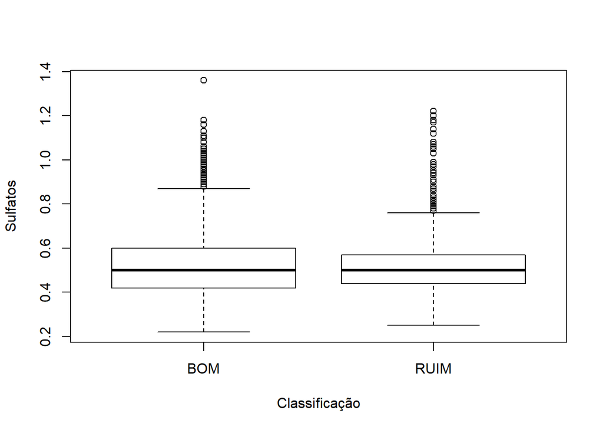

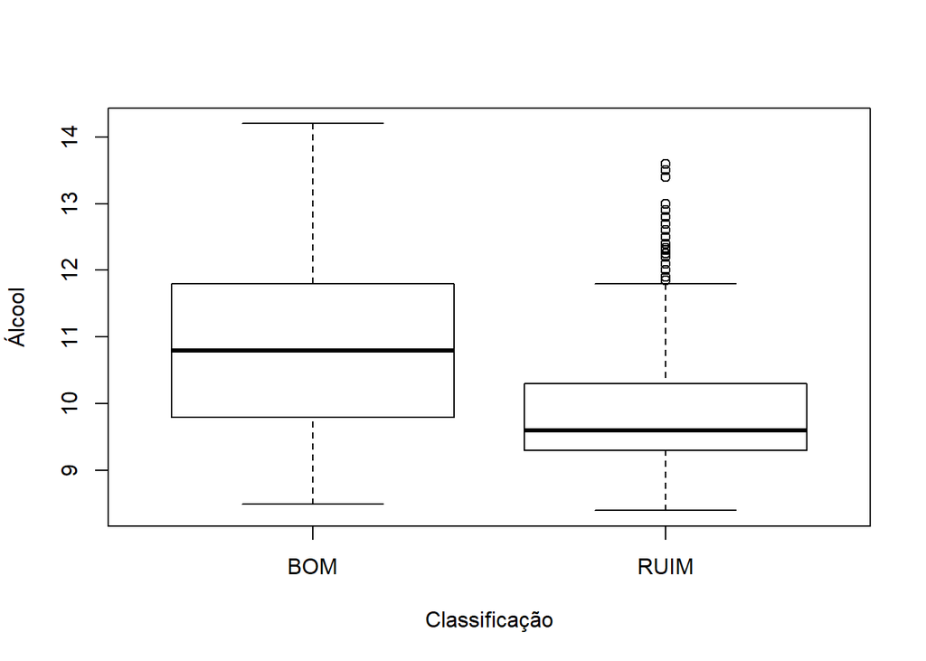

Realizamos um novo filtro nos outliers com base na classificação:

```r
filtered %>% filter(citricacid <= 0.8) -> filtered
filtered %>% filter(residualsugar <= 22) -> filtered
filtered %>% filter(freesulfurdioxide <= 120) -> filtered
filtered %>% filter(totalsulfurdioxide <= 300) -> filtered
filtered %>% filter(sulphates <= 1.2) -> filtered
filtered %>% filter(pH > 2.8) -> filtered
```

E visualizamos os dados sem outliers:

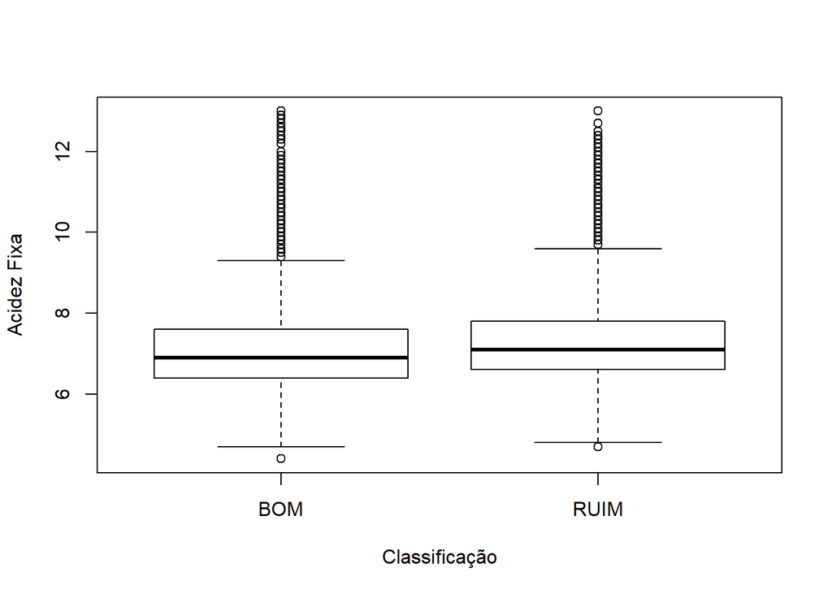

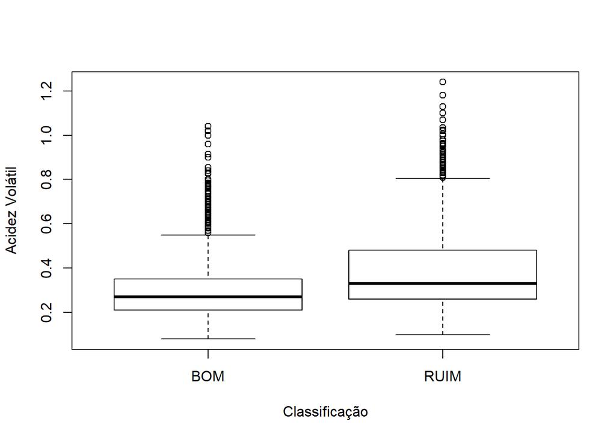

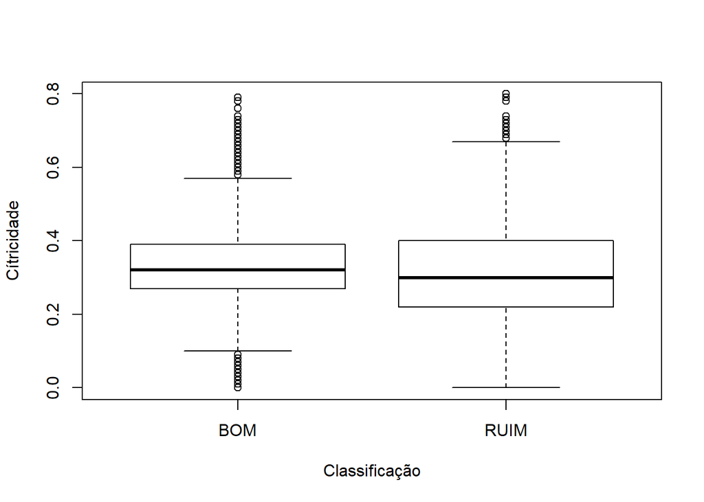

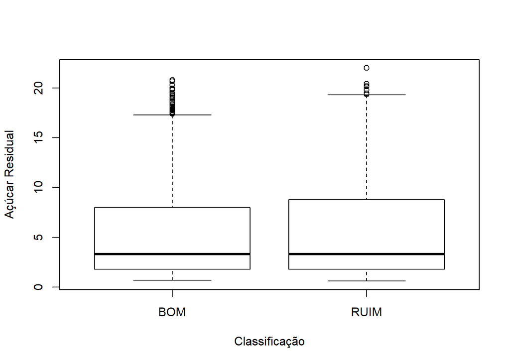

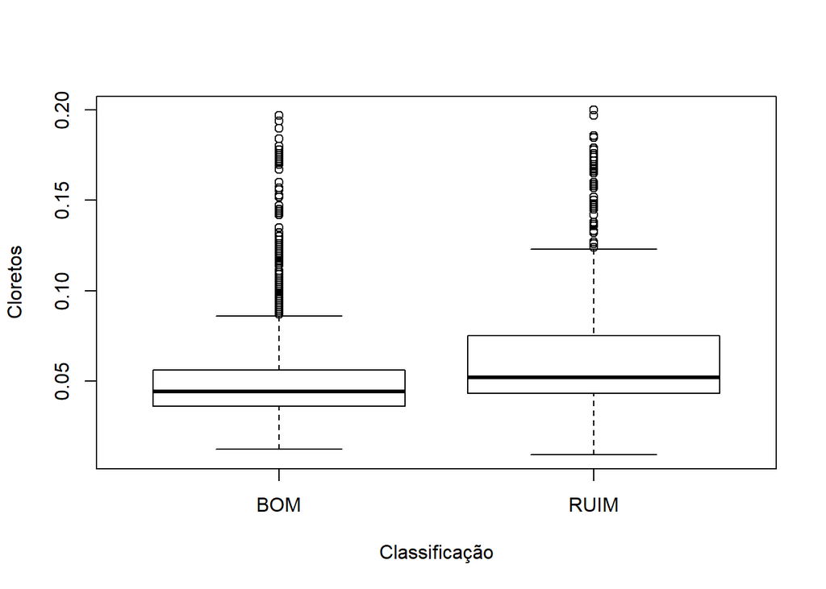

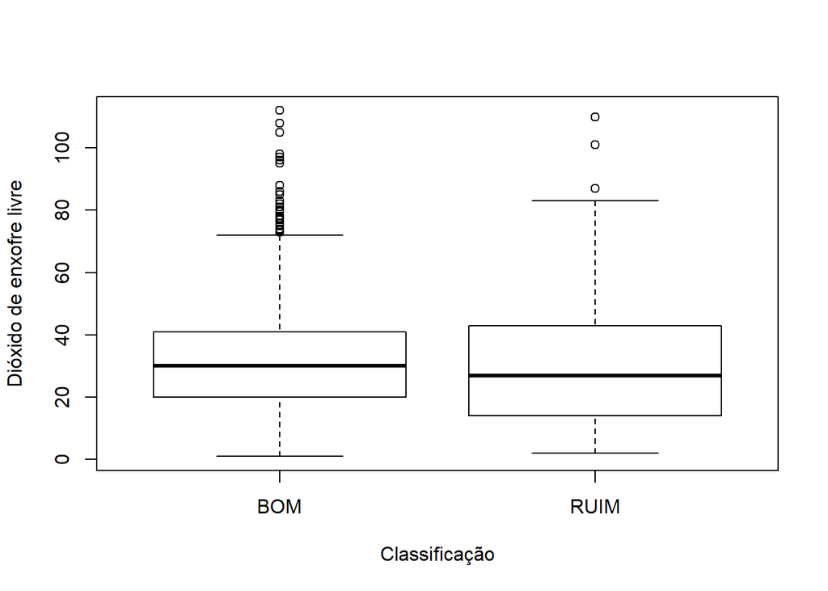

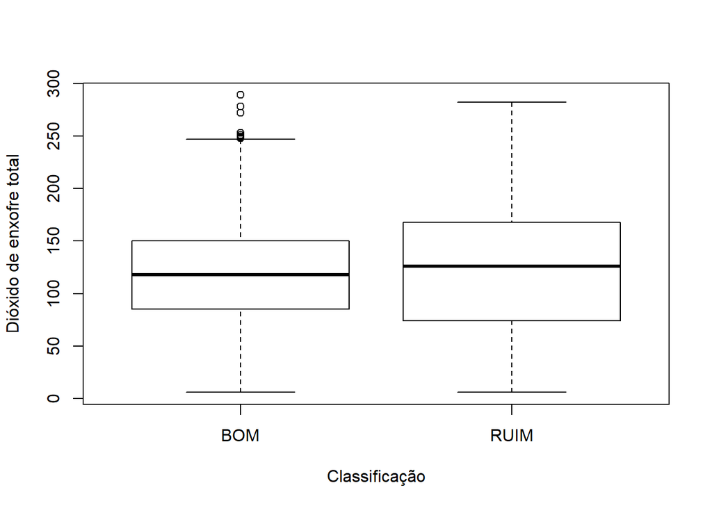

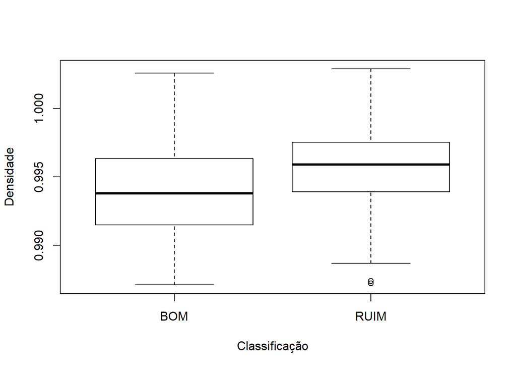

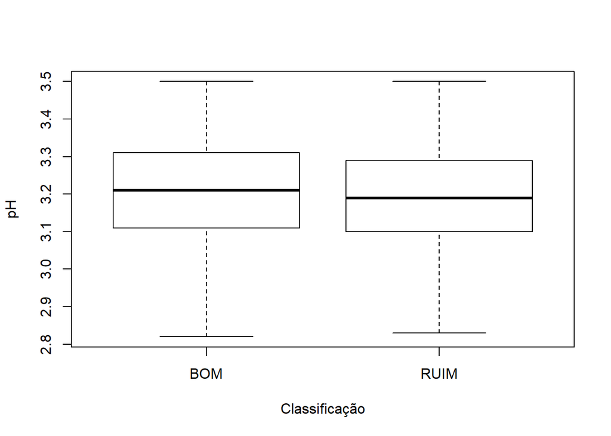

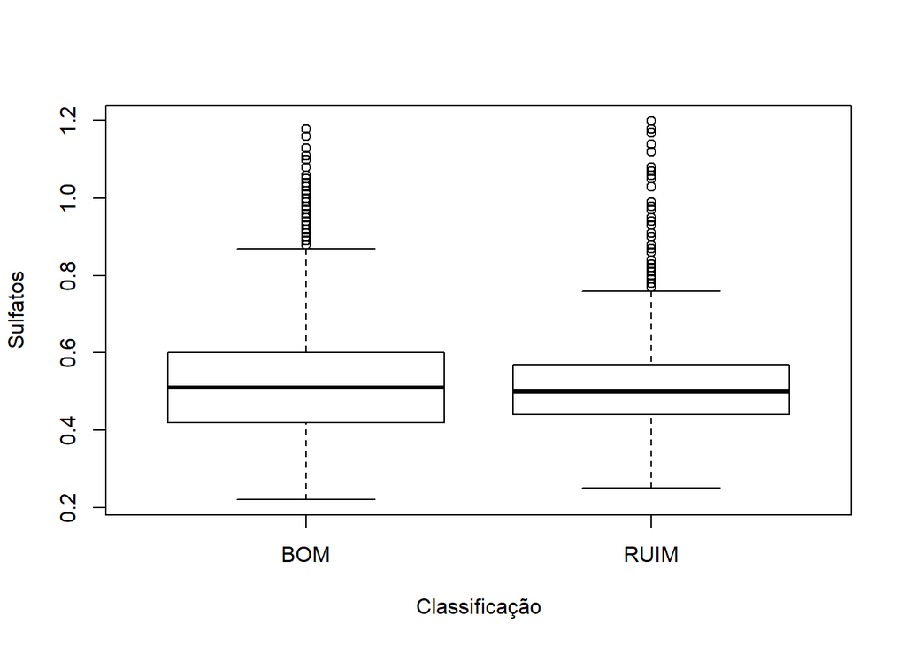

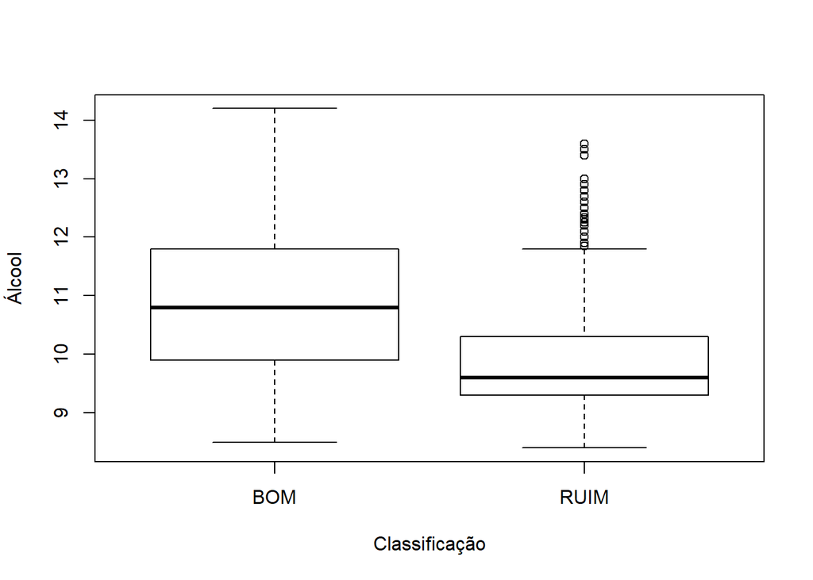

Executamos uma nova matriz de correlação em função da classificação:

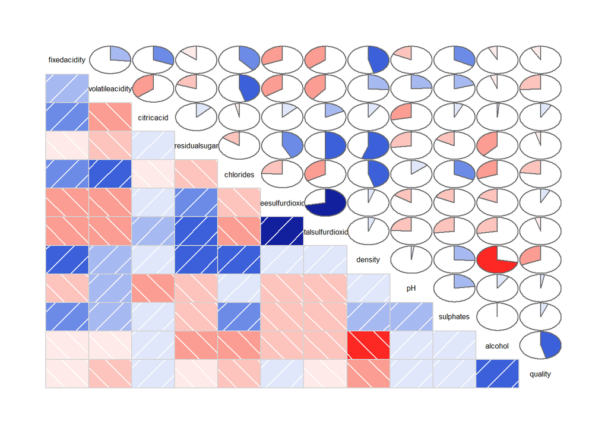

```r
#Rodar matriz de correlação
corMatrix <- cor(filtered %>% select(-Vinho,-classificacao))

#Visualizar a matriz de correlação
corrgram(corMatrix, type = "cor", lower.panel = panel.shade, upper.panel = panel.pie)
```

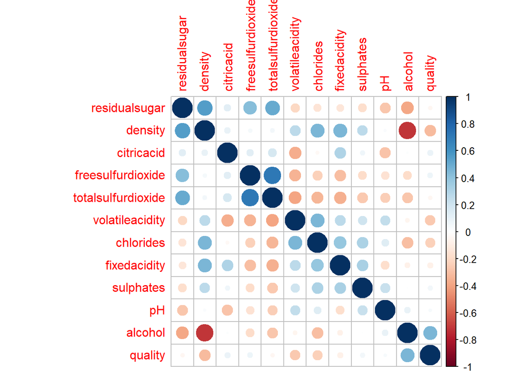

```r
corrplot::corrplot(corMatrix, method="circle", order="hclust")
```

Rodamos o modelo de regressão logistica:

```r
# Modelo de regressão logistica
regressionModel <- glm(filtered$classificacao ~ filtered$fixedacidity + filtered$citricacid + filtered$residualsugar + filtered$chlorides + filtered$freesulfurdioxide + filtered$totalsulfurdioxide + filtered$density + filtered$pH + filtered$sulphates + filtered$alcohol, family =binomial(link="logit"))

summary(regressionModel)
```

```
##
## Call:
## glm(formula = filtered$classificacao ~ filtered$fixedacidity +
##     filtered$citricacid + filtered$residualsugar + filtered$chlorides +
##     filtered$freesulfurdioxide + filtered$totalsulfurdioxide +
##     filtered$density + filtered$pH + filtered$sulphates + filtered$alcohol,
##     family = binomial(link = "logit"))
##
## Deviance Residuals:
##     Min       1Q   Median       3Q      Max
## -2.0235  -0.8529  -0.4241   0.9649   2.9827
##
## Coefficients:
##                               Estimate Std. Error z value Pr(>|z|)
## (Intercept)                 -3.286e+02  4.308e+01  -7.628 2.38e-14 ***
## filtered$fixedacidity       -2.418e-01  5.556e-02  -4.352 1.35e-05 ***
## filtered$citricacid         -8.167e-01  2.485e-01  -3.286  0.00102 **
## filtered$residualsugar      -1.877e-01  1.792e-02 -10.473  < 2e-16 ***
## filtered$chlorides           2.627e+00  1.677e+00   1.566  0.11733
## filtered$freesulfurdioxide  -2.225e-02  2.648e-03  -8.403  < 2e-16 ***
## filtered$totalsulfurdioxide  7.133e-03  9.137e-04   7.806 5.91e-15 ***
## filtered$density             3.456e+02  4.397e+01   7.861 3.82e-15 ***
## filtered$pH                 -1.702e+00  3.330e-01  -5.111 3.20e-07 ***
## filtered$sulphates          -2.929e+00  2.992e-01  -9.791  < 2e-16 ***
## filtered$alcohol            -5.926e-01  6.172e-02  -9.600  < 2e-16 ***
## ---
## Signif. codes:  0 '***' 0.001 '**' 0.01 '*' 0.05 '.' 0.1 ' ' 1
##
## (Dispersion parameter for binomial family taken to be 1)
##
##     Null deviance: 7927.3  on 6052  degrees of freedom
## Residual deviance: 6412.7  on 6042  degrees of freedom
## AIC: 6434.7
##
## Number of Fisher Scoring iterations: 5
```

```r
stepwise<-step(regressionModel,direction="both")
```

```
## Start:  AIC=6434.69
## filtered$classificacao ~ filtered$fixedacidity + filtered$citricacid +
##     filtered$residualsugar + filtered$chlorides + filtered$freesulfurdioxide +
##     filtered$totalsulfurdioxide + filtered$density + filtered$pH +
##     filtered$sulphates + filtered$alcohol
##
##                               Df Deviance    AIC
## <none>                             6412.7 6434.7
## - filtered$chlorides           1   6415.2 6435.2
## - filtered$citricacid          1   6423.5 6443.5
## - filtered$fixedacidity        1   6431.7 6451.7
## - filtered$pH                  1   6439.0 6459.0
## - filtered$totalsulfurdioxide  1   6474.3 6494.3
## - filtered$density             1   6474.8 6494.8
## - filtered$freesulfurdioxide   1   6485.8 6505.8
## - filtered$alcohol             1   6507.9 6527.9
## - filtered$sulphates           1   6513.9 6533.9
## - filtered$residualsugar       1   6524.7 6544.7
```

```r
summary(stepwise)
```

```
##
## Call:
## glm(formula = filtered$classificacao ~ filtered$fixedacidity +
##     filtered$citricacid + filtered$residualsugar + filtered$chlorides +
##     filtered$freesulfurdioxide + filtered$totalsulfurdioxide +
##     filtered$density + filtered$pH + filtered$sulphates + filtered$alcohol,
##     family = binomial(link = "logit"))
##
## Deviance Residuals:
##     Min       1Q   Median       3Q      Max
## -2.0235  -0.8529  -0.4241   0.9649   2.9827
##
## Coefficients:
##                               Estimate Std. Error z value Pr(>|z|)
## (Intercept)                 -3.286e+02  4.308e+01  -7.628 2.38e-14 ***
## filtered$fixedacidity       -2.418e-01  5.556e-02  -4.352 1.35e-05 ***
## filtered$citricacid         -8.167e-01  2.485e-01  -3.286  0.00102 **
## filtered$residualsugar      -1.877e-01  1.792e-02 -10.473  < 2e-16 ***
## filtered$chlorides           2.627e+00  1.677e+00   1.566  0.11733
## filtered$freesulfurdioxide  -2.225e-02  2.648e-03  -8.403  < 2e-16 ***
## filtered$totalsulfurdioxide  7.133e-03  9.137e-04   7.806 5.91e-15 ***
## filtered$density             3.456e+02  4.397e+01   7.861 3.82e-15 ***
## filtered$pH                 -1.702e+00  3.330e-01  -5.111 3.20e-07 ***
## filtered$sulphates          -2.929e+00  2.992e-01  -9.791  < 2e-16 ***
## filtered$alcohol            -5.926e-01  6.172e-02  -9.600  < 2e-16 ***
## ---
## Signif. codes:  0 '***' 0.001 '**' 0.01 '*' 0.05 '.' 0.1 ' ' 1
##
## (Dispersion parameter for binomial family taken to be 1)
##
##     Null deviance: 7927.3  on 6052  degrees of freedom
## Residual deviance: 6412.7  on 6042  degrees of freedom
## AIC: 6434.7
##
## Number of Fisher Scoring iterations: 5
```

Podemos analisar que a variavel chlorides o seu p value deu maior que 0.05, ou seja, essa vairavel não é muito significante na classificação do vinho, então ela pode ser retirada.

```r
decisionTree <- rpart(filtered$classificacao ~ filtered$fixedacidity + filtered$citricacid + filtered$residualsugar + filtered$chlorides + filtered$freesulfurdioxide + filtered$totalsulfurdioxide + filtered$density + filtered$pH + filtered$sulphates + filtered$alcohol,
             data=filtered, cp=0.005)

printcp(decisionTree)
```

```
##
## Classification tree:
## rpart(formula = filtered$classificacao ~ filtered$fixedacidity +
##     filtered$citricacid + filtered$residualsugar + filtered$chlorides +
##     filtered$freesulfurdioxide + filtered$totalsulfurdioxide +
##     filtered$density + filtered$pH + filtered$sulphates + filtered$alcohol,
##     data = filtered, cp = 0.005)
##
## Variables actually used in tree construction:
## [1] filtered$alcohol            filtered$chlorides
## [3] filtered$citricacid         filtered$freesulfurdioxide
## [5] filtered$residualsugar      filtered$sulphates
## [7] filtered$totalsulfurdioxide
##
## Root node error: 2194/6053 = 0.36246
##
## n= 6053
##
##           CP nsplit rel error  xerror     xstd
## 1  0.1125798      0   1.00000 1.00000 0.017046
## 2  0.0528715      1   0.88742 0.88195 0.016537
## 3  0.0259799      3   0.78168 0.80720 0.016133
## 4  0.0191431      4   0.75570 0.76800 0.015893
## 5  0.0113947      5   0.73655 0.75387 0.015802
## 6  0.0091158      6   0.72516 0.74840 0.015766
## 7  0.0088879      7   0.71604 0.74157 0.015721
## 8  0.0068368      9   0.69827 0.73655 0.015687
## 9  0.0063810     10   0.69143 0.73108 0.015650
## 10 0.0052416     12   0.67867 0.71787 0.015558
## 11 0.0050000     16   0.65770 0.71376 0.015529
```

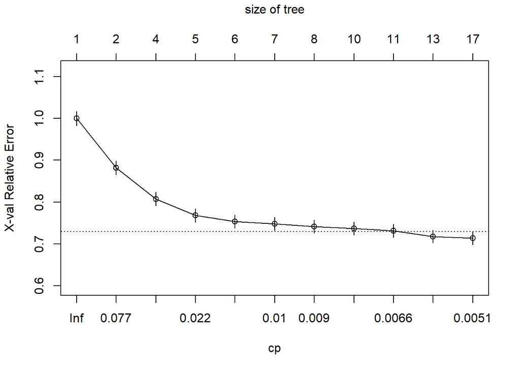

```r
plotcp(decisionTree)
```

```r
summary(decisionTree)
```

```
## Call:
## rpart(formula = filtered$classificacao ~ filtered$fixedacidity +
##     filtered$citricacid + filtered$residualsugar + filtered$chlorides +
##     filtered$freesulfurdioxide + filtered$totalsulfurdioxide +
##     filtered$density + filtered$pH + filtered$sulphates + filtered$alcohol,
##     data = filtered, cp = 0.005)
##   n= 6053
##
##             CP nsplit rel error    xerror       xstd
## 1  0.112579763      0 1.0000000 1.0000000 0.01704644
## 2  0.052871468      1 0.8874202 0.8819508 0.01653719
## 3  0.025979945      3 0.7816773 0.8072015 0.01613283
## 4  0.019143118      4 0.7556974 0.7680036 0.01589349
## 5  0.011394713      5 0.7365542 0.7538742 0.01580239
## 6  0.009115770      6 0.7251595 0.7484047 0.01576642
## 7  0.008887876      7 0.7160438 0.7415679 0.01572090
## 8  0.006836828      9 0.6982680 0.7365542 0.01568713
## 9  0.006381039     10 0.6914312 0.7310848 0.01564989
## 10 0.005241568     12 0.6786691 0.7178669 0.01555824
## 11 0.005000000     16 0.6577028 0.7137648 0.01552930
##
## Variable importance
##            filtered$alcohol            filtered$density
##                          31                          17
##          filtered$chlorides filtered$totalsulfurdioxide
##                          13                          11
##      filtered$residualsugar  filtered$freesulfurdioxide
##                           9                           8
##         filtered$citricacid          filtered$sulphates
##                           5                           2
##       filtered$fixedacidity
##                           2
##
## Node number 1: 6053 observations,    complexity param=0.1125798
##   predicted class=BOM   expected loss=0.3624649  P(node) =1
##     class counts:  3859  2194
##    probabilities: 0.638 0.362
##   left son=2 (2972 obs) right son=3 (3081 obs)
##   Primary splits:
##       filtered$alcohol            < 10.35     to the right, improve=395.93580, (0 missing)
```

[output cut: 343 more lines]

```
##
## Node number 61: 142 observations
##   predicted class=RUIM  expected loss=0.3028169  P(node) =0.02345944
##     class counts:    43    99
##    probabilities: 0.303 0.697
##
## Node number 96: 952 observations
##   predicted class=BOM   expected loss=0.3245798  P(node) =0.1572774
##     class counts:   643   309
##    probabilities: 0.675 0.325
##
## Node number 97: 42 observations
##   predicted class=RUIM  expected loss=0.2619048  P(node) =0.006938708
##     class counts:    11    31
##    probabilities: 0.262 0.738
```

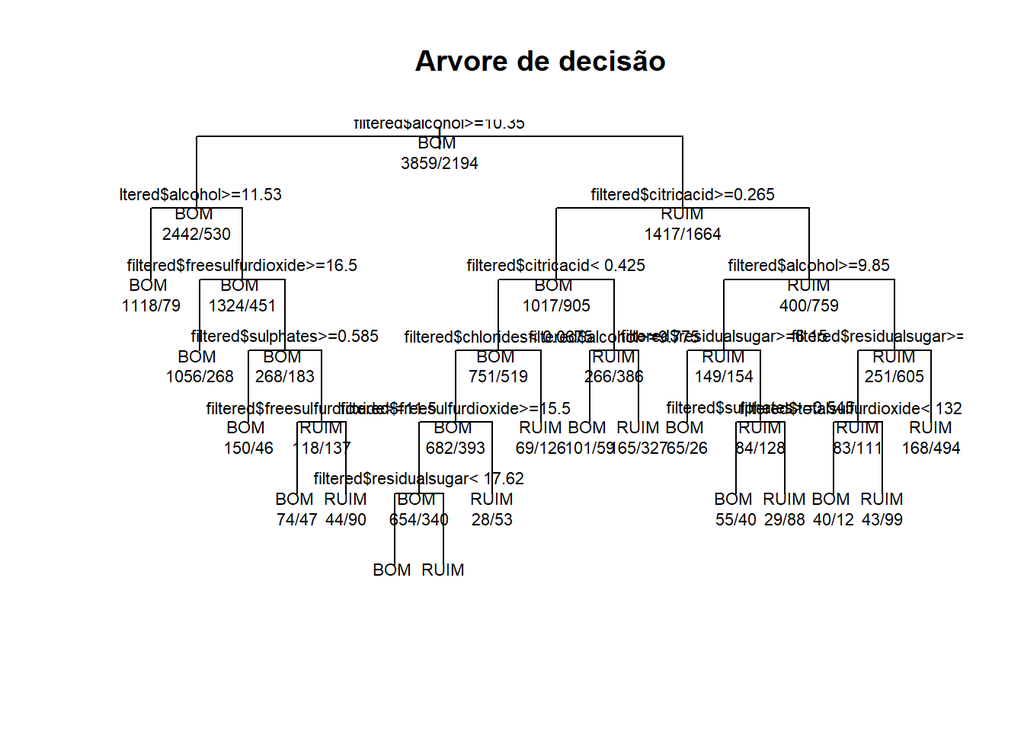

```r
plot(decisionTree, uniform=TRUE,
     main="Arvore de decisão")
text(decisionTree, use.n=TRUE, all=TRUE, cex=.7)
```

```r
#Verifica a acertividade do modelo
sqrt(mean((filtered$quality - predict(regressionModel))^2))
```

```
## [1] 6.895892
```

```r
sqrt(mean((filtered$quality - predict(decisionTree))^2))
```

```
## [1] 5.408395
```